# Differential Gene Expression Analysis

Pan-cancer | Multiple RCD types

Mark Edward M. Gonzales[^1]

Dr. Anish M.S. Shrestha[^2]

## I. Preliminaries

### Loading libraries

```r
library("tidyverse")
library("tibble")
library("msigdbr")
library("ggplot2")
library("TCGAbiolinks")
library("RNAseqQC")
library("DESeq2")
library("ensembldb")
library("purrr")
library("magrittr")
library("vsn")
library("matrixStats")
library("dplyr")
library("grex")
```

## II. Downloading the TCGA gene expression data

Create a function for downloading TCGA gene expression data.

For more detailed documentation, refer to `2. Differential Gene Expression Analysis - TCGA.Rmd`.

```r
GDC_DIR = "../data/public/GDCdata"

query_and_filter_samples <- function(project) {
  query_tumor <- GDCquery(
    project = project,
    data.category = "Transcriptome Profiling",
    data.type = "Gene Expression Quantification",
    experimental.strategy = "RNA-Seq",
    workflow.type = "STAR - Counts",
    access = "open",
    sample.type = "Primary Tumor"
  )
  tumor <- getResults(query_tumor)

  query_normal <- GDCquery(
    project = project,
    data.category = "Transcriptome Profiling",
    data.type = "Gene Expression Quantification",
    experimental.strategy = "RNA-Seq",
    workflow.type = "STAR - Counts",
    access = "open",
    sample.type = "Solid Tissue Normal"
  )
  normal <- getResults(query_normal)

  submitter_ids <- inner_join(tumor, normal, by = "cases.submitter_id") %>%
    dplyr::select(cases.submitter_id)
  tumor <- tumor %>%
    dplyr::filter(cases.submitter_id %in% submitter_ids$cases.submitter_id)
  normal <- normal %>%
    dplyr::filter(cases.submitter_id %in% submitter_ids$cases.submitter_id)

  samples <- rbind(tumor, normal)
  unique(samples$sample_type)

  query_project <- GDCquery(
    project = project,
    data.category = "Transcriptome Profiling",
    data.type = "Gene Expression Quantification",
    experimental.strategy = "RNA-Seq",
    workflow.type = "STAR - Counts",
    access = "open",
    sample.type = c("Solid Tissue Normal", "Primary Tumor"),
    barcode = as.list(samples$sample.submitter_id)
  )

  # If this is your first time running this notebook (i.e., you have not yet downloaded the results of the query in the previous block),
  # uncomment the code block below

  # GDCdownload(
  #   query_coad,
  #   directory = GDC_DIR
  # )

  return(list(samples = samples, query_project = query_project))
}
```

Download the TCGA gene expression data for different cancer types.

Refer to this link for the list of TCGA cancer type abbreviations: https://gdc.cancer.gov/resources-tcga-users/tcga-code-tables/tcga-study-abbreviations

```r
projects <- c(
  "TCGA-LUSC", "TCGA-COAD", "TCGA-KICH", "TCGA-KIRC", "TCGA-PRAD",
  "TCGA-BRCA", "TCGA-HNSC", "TCGA-KIRP", "TCGA-LIHC", "TCGA-STAD",
  "TCGA-THCA", "TCGA-BLCA", "TCGA-LUAD", "TCGA-ESCA"
)

samples <- list()
project_data <- list()

for (project in projects) {
  result <- query_and_filter_samples(project)

  samples[[project]] <- result$samples
  project_data[[project]] <- result$query_project
}
```

Running the code block above should generate and populate a directory named `GDCdata`.

## III. Data preprocessing

Construct the RNA-seq count matrix for each cancer type.

```r
tcga_data <- list()
tcga_matrix <- list()

for (project in projects) {
  tcga_data[[project]] <- GDCprepare(
    project_data[[project]],
    directory = GDC_DIR,
    summarizedExperiment = TRUE
  )
}
```

```r
for (project in projects) {
  count_matrix <- assay(tcga_data[[project]], "unstranded")

  # Remove duplicate entries
  count_matrix_df <- data.frame(count_matrix)
  count_matrix_df <- count_matrix_df[!duplicated(count_matrix_df), ]
  count_matrix <- data.matrix(count_matrix_df)
  rownames(count_matrix) <- cleanid(rownames(count_matrix))
  count_matrix <- count_matrix[!(duplicated(rownames(count_matrix)) | duplicated(rownames(count_matrix), fromLast = TRUE)), ]

  tcga_matrix[[project]] <- count_matrix
}
```

Format the `samples` table so that it can be fed as input to DESeq2.

```r
for (project in projects) {
  rownames(samples[[project]]) <- samples[[project]]$cases
  samples[[project]] <- samples[[project]] %>%
    dplyr::select(case = "cases.submitter_id", type = "sample_type")
  samples[[project]]$type <- str_replace(samples[[project]]$type, "Solid Tissue Normal", "normal")
  samples[[project]]$type <- str_replace(samples[[project]]$type, "Primary Tumor", "tumor")
}
```

DESeq2 requires the row names of `samples` should be identical to the column names of `count_matrix`.

```r
for (project in projects) {
  colnames(tcga_matrix[[project]]) <- gsub(x = colnames(tcga_matrix[[project]]), pattern = "\\.", replacement = "-")
  tcga_matrix[[project]] <- tcga_matrix[[project]][, rownames(samples[[project]])]

  # Sanity check
  print(all(colnames(tcga_matrix[[project]]) == rownames(samples[[project]])))
}
```

## IV. Differential gene expression analysis

References:

- Official documentation: https://www.bioconductor.org/packages/release/bioc/vignettes/DESeq2/inst/doc/DESeq2.html
- Good balance of theory and hands-on: https://hbctraining.github.io/DGE_workshop/lessons/04_DGE_DESeq2_analysis.html
- Quality control: https://cran.r-project.org/web/packages/RNAseqQC/vignettes/introduction.html

Construct the `DESeqDataSet` object for each cancer type.

```r
dds_results <- list()

for (project in projects) {
  dds_results[[project]] <- DESeqDataSetFromMatrix(
    countData = tcga_matrix[[project]],
    colData = samples[[project]],
    design = ~type
  )
}
```

### Regulated Cell Death

We obtain the gene sets from RCDdb: https://pmc.ncbi.nlm.nih.gov/articles/PMC11384979/

```r
RCDdb <- "../data/public/rcd-gene-list/RCDdb/"
```

Write utility functions for filtering the gene sets, performing differential gene expression analysis, and plotting the results.

```r
filter_gene_set_and_perform_dgea <- function(genes) {
  tcga_rcd <- list()

  for (project in projects) {
    rownames(genes) <- genes$gene_id
    tcga_rcd[[project]] <- tcga_matrix[[project]][rownames(tcga_matrix[[project]]) %in% genes$gene_id, ]
    tcga_rcd[[project]] <- tcga_rcd[[project]][, rownames(samples[[project]])]
  }

  dds_rcd <- list()
  res_rcd <- list()

  for (project in projects) {
    print(project)
    print("=============")
    dds <- DESeqDataSetFromMatrix(
      countData = tcga_rcd[[project]],
      colData = samples[[project]],
      design = ~type
    )
    dds <- filter_genes(dds, min_count = 10)
    dds$type <- relevel(dds$type, ref = "normal")
    dds_rcd[[project]] <- DESeq(dds)
    res_rcd[[project]] <- results(dds_rcd[[project]])
  }

  deseq.bbl.data <- list()

  for (project in projects) {
    deseq.results <- res_rcd[[project]]
    deseq.bbl.data[[project]] <- data.frame(
      row.names = rownames(deseq.results),
      baseMean = deseq.results$baseMean,
      log2FoldChange = deseq.results$log2FoldChange,
      lfcSE = deseq.results$lfcSE,
      stat = deseq.results$stat,
      pvalue = deseq.results$pvalue,
      padj = deseq.results$padj,
      cancer_type = project,
      gene_symbol = genes[rownames(deseq.results), "gene"]
    )
  }

  deseq.bbl.data.combined <- bind_rows(deseq.bbl.data)
  deseq.bbl.data.combined <- dplyr::filter(deseq.bbl.data.combined, abs(log2FoldChange) >= 1.5 & padj < 0.05)

  return(deseq.bbl.data.combined)
}
```

```r
plot_dgea <- function(deseq.bbl.data.combined) {
  sizes <- c("<10^-15" = 4, "10^-10" = 3, "10^-5" = 2, "0.05" = 1)

  deseq.bbl.data.combined <- deseq.bbl.data.combined %>%
    mutate(fdr_category = cut(padj,
      breaks = c(-Inf, 1e-15, 1e-10, 1e-5, 0.05),
      labels = c("<10^-15", "10^-10", "10^-5", "0.05"),
      right = FALSE
    ))

  top_genes <- deseq.bbl.data.combined %>%
    group_by(cancer_type) %>%
    mutate(rank = rank(-abs(log2FoldChange))) %>%
    dplyr::filter(rank <= 10) %>%
    ungroup()

  ggplot(top_genes, aes(y = cancer_type, x = gene_symbol, size = fdr_category, fill = log2FoldChange)) +
    geom_point(alpha = 0.5, shape = 21, color = "black") +
    scale_size_manual(values = sizes) +
    scale_fill_gradient2(low = "blue", mid = "white", high = "red", limits = c(min(deseq.bbl.data.combined$log2FoldChange), max(deseq.bbl.data.combined$log2FoldChange))) +
    theme_minimal() +
    theme(
      axis.text.x = element_text(size = 9, angle = 90, hjust = 1)
    ) +
    theme(legend.position = "bottom") +
    theme(legend.position = "bottom") +
    labs(size = "Adjusted p-value", fill = "log2 FC", y = "Cancer type", x = "Gene")
}
```

#### 1. Necroptosis

Fetch the gene set of interest.

```r
genes <- read.csv(paste0(RCDdb, "Necroptosis.csv"))
genes$gene_id <- cleanid(genes$gene_id)
genes <- distinct(genes, gene_id, .keep_all = TRUE)
genes <- subset(genes, gene_id != "")
genes
```

|  | deathtype | gene | description | gene_id | gene_biotype | pmid | comment |
| --- | --- | --- | --- | --- | --- | --- | --- |
| 1 | Necroptosis | GLUD1 | glutamate dehydrogenase 1 | ENSG00000148672 | protein_coding | 30029665 | The activation of GLUD1 led to the disruption of metabolic balance and cell death. Resibufogenin induces cell death dependent on necroptosis by activating RIP3 and phosphorylating mixed lineage kinase… |
| 2 | Necroptosis | ALOX15 | arachidonate 15-lipoxygenase | ENSG00000161905 | protein_coding | 29891910 | Necroptosis occurred in the skin in the absence of ALOX15. In addition, apoptosis markers were also upregulated in the dorsal skin of ALOX15 KO mice. ALOX15 plays a critical role in maintaining skin h… |
| 3 | Necroptosis | FTH1 | ferritin heavy chain 1 | ENSG00000167996 | protein_coding | 32984939 | Low concentrations of boron can promote cell proliferation and differentiation by inhibiting the expression of FTH1, reducing iron ion accumulation and ROS production in cells, and thereby reducing ce… |
| 4 | Necroptosis | CAPN1 | calpain 1 | ENSG00000014216 | protein_coding | 37168851 | CAPN1 activation has been demonstrated to degrade cytoskeleton proteins, vital enzymes, and mitochondrial membrane-related proteins, which may play a primary role in ischemia-induced neuronal injury, … |
| 5 | Necroptosis | CASP1 | caspase 1 | ENSG00000137752 | protein_coding | 36389690 | CASP1 is involved in the regulation of necroptosis. In this study, CASP1 was one of the three selected necroptosis-related genes used to construct a prognostic model and risk score system to predict t… |
| 6 | Necroptosis | BAX | BCL2 associated X, apoptosis regulator | ENSG00000087088 | protein_coding | 32768820 | Chlorpyrifos (CPF) could promote the expression of BAX mRNA and protein and induce apoptosis and necroptosis of L8824 cells. CPF could also activate the expression of genes related to the Necroptosis … |
| 7 | Necroptosis | BCL2 | BCL2 apoptosis regulator | ENSG00000171791 | protein_coding | 31634424 | Fisetin can reduce the expression of the anti-apoptotic protein BCL2 and increase the levels of pro-apoptotic proteins Bax, caspase-3, and PARP in HepG2 cells, inducing cell death through apoptosis pa… |
| 8 | Necroptosis | FADD | Fas associated via death domain | ENSG00000168040 | protein_coding | 36191211 | The absence of Caspase-8 or FADD can lead to spontaneous activation of RIPK3, phosphorylation of MLKL, and necroptosis.the proteolytic activity of the FADD/Caspase-8 complex can inhibit ZBP1-induced n… |
| 9 | Necroptosis | RIPK1 | receptor interacting serine/threonine kinase 1 | ENSG00000137275 | protein_coding | 27493188 | The absence of Optineurin leads to progressive dysmyelination and axonal degeneration in the central nervous system through the engagement of Necroptotic machinery, including RIPK1, RIPK3, and MLKL. I… |
| 10 | Necroptosis | TNF | tumor necrosis factor | ENSG00000232810 | protein_coding | 31221990 | TNF is one of the key factors in the formation of Necroptosis, inducing the formation of RIPK1 and RIPK3 Necrosome through TNFR1 in different cell types, which leads to the phosphorylation and oligome… |

[output cut: 73 more lines]

Filter the genes to include only those in the gene set of interest, and then perform differential gene expression analysis.

```r
deseq.bbl.data.combined <- filter_gene_set_and_perform_dgea(genes)
```

```
[1] "TCGA-LUSC"
[1] "============="
```

```
[1] "TCGA-COAD"
[1] "============="
```

```
[1] "TCGA-KICH"
[1] "============="
```

```
[1] "TCGA-KIRC"
[1] "============="
```

```
[1] "TCGA-PRAD"
[1] "============="
```

```
[1] "TCGA-BRCA"
[1] "============="
```

```
[1] "TCGA-HNSC"
[1] "============="
```

```
[1] "TCGA-KIRP"
[1] "============="
```

```
[1] "TCGA-LIHC"
[1] "============="
```

```
[1] "TCGA-STAD"
[1] "============="
```

```
[1] "TCGA-THCA"
[1] "============="
```

```
[1] "TCGA-BLCA"
[1] "============="
```

```
[1] "TCGA-LUAD"
[1] "============="
```

```
[1] "TCGA-ESCA"
[1] "============="
```

```r
deseq.bbl.data.combined
```

|  | baseMean | log2FoldChange | lfcSE | stat | pvalue | padj | cancer_type | gene_symbol |
| --- | --- | --- | --- | --- | --- | --- | --- | --- |
| ENSG00000136869 | 2808.233597 | -2.089890 | 0.1544995 | -13.526835 | 1.085991e-41 | 2.932175e-40 | TCGA-LUSC | TLR4 |
| ENSG00000137033...2 | 4339.525614 | -2.025762 | 0.2560924 | -7.910280 | 2.568099e-15 | 1.223624e-14 | TCGA-LUSC | IL33 |
| ENSG00000162711...3 | 572.267048 | -1.761106 | 0.1967112 | -8.952747 | 3.467427e-19 | 2.553287e-18 | TCGA-LUSC | NLRP3 |
| ENSG00000164342...4 | 1084.970581 | -1.679867 | 0.1523690 | -11.024989 | 2.895530e-28 | 3.350542e-27 | TCGA-LUSC | TLR3 |
| ENSG00000165168...5 | 10885.822813 | -1.898175 | 0.1908481 | -9.945996 | 2.625338e-23 | 2.126524e-22 | TCGA-LUSC | CYBB |
| ENSG00000247077 | 3328.468125 | 1.519344 | 0.1014797 | 14.971897 | 1.120782e-50 | 9.078338e-49 | TCGA-LUSC | PGAM5 |
| ENSG00000082512 | 1712.960718 | 1.684443 | 0.1570555 | 10.725142 | 7.756770e-27 | 1.256597e-25 | TCGA-COAD | TRAF5 |
| ENSG00000115008...8 | 52.405943 | 2.717319 | 0.3051978 | 8.903469 | 5.412770e-19 | 3.985767e-18 | TCGA-COAD | IL1A |
| ENSG00000164342...9 | 889.239677 | -1.773074 | 0.1592982 | -11.130529 | 8.910516e-29 | 1.804379e-27 | TCGA-COAD | TLR3 |
| ENSG00000166311 | 2218.342115 | -1.635454 | 0.1212918 | -13.483627 | 1.952661e-41 | 1.581655e-39 | TCGA-COAD | SMPD1 |

[output cut: 47 more lines]

Plot the results.

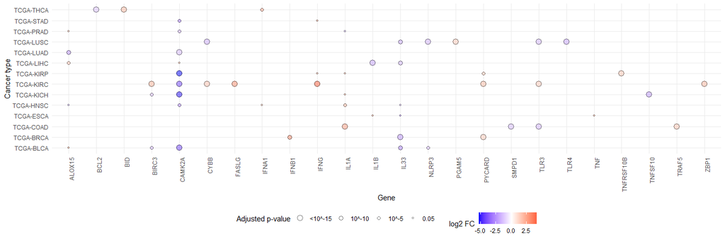

```r
plot_dgea(deseq.bbl.data.combined)
```

#### 2. Ferroptosis

Fetch the gene set of interest.

```r
genes <- read.csv(paste0(RCDdb, "Ferroptosis.csv"))
genes$gene_id <- cleanid(genes$gene_id)
genes <- distinct(genes, gene_id, .keep_all = TRUE)
genes <- subset(genes, gene_id != "")
genes
```

|  | deathtype | gene | description | gene_id | gene_biotype | pmid | comment |
| --- | --- | --- | --- | --- | --- | --- | --- |
| 1 | Ferroptosis | RPL8 | ribosomal protein L8 | ENSG00000161016 | protein_coding | 22632970 | Required in erastin-induced ferroptosis. Silencing of it conferred against erastin-induced ferroptosis. |
| 2 | Ferroptosis | IREB2 | iron responsive element binding protein 2 | ENSG00000136381 | protein_coding | 22632970 | Required in erastin-induced ferroptosis. Silencing of it conferred against erastin-induced ferroptosis. |
| 3 | Ferroptosis | ATP5MC3 | ATP synthase membrane subunit c locus 3 | ENSG00000154518 | protein_coding | 22632970 | Required in erastin-induced ferroptosis. Silencing of it conferred against erastin-induced ferroptosis. |
| 4 | Ferroptosis | CS | citrate synthase | ENSG00000062485 | protein_coding | 22632970 | Required in erastin-induced ferroptosis. Silencing of it conferred against erastin-induced ferroptosis. |
| 5 | Ferroptosis | EMC2 | ER membrane protein complex subunit 2 | ENSG00000104412 | protein_coding | 22632970 | Required in erastin-induced ferroptosis. Silencing of it conferred against erastin-induced ferroptosis. |
| 6 | Ferroptosis | ACSF2 | acyl-CoA synthetase family member 2 | ENSG00000167107 | protein_coding | 22632970 | Required in erastin-induced ferroptosis. Silencing of it conferred against erastin-induced ferroptosis. |
| 7 | Ferroptosis | NOX1 | NADPH oxidase 1 | ENSG00000007952 | protein_coding | 22632970 | Suppresses erastin-induced ferroptosis when inhibited by inhibitor. |
| 8 | Ferroptosis | CYBB | cytochrome b-245 beta chain | ENSG00000165168 | protein_coding | 22632970 | Suppresses erastin-induced ferroptosis when inhibited by inhibitor. |
| 9 | Ferroptosis | NOX3 | NADPH oxidase 3 | ENSG00000074771 | protein_coding | 22632970 | Suppresses erastin-induced ferroptosis when inhibited by inhibitor. |
| 10 | Ferroptosis | NOX4 | NADPH oxidase 4 | ENSG00000086991 | protein_coding | 22632970 | Suppresses erastin-induced ferroptosis when inhibited by inhibitor. |

[output cut: 539 more lines]

Filter the genes to include only those in the gene set of interest, and then perform differential gene expression analysis.

```r
deseq.bbl.data.combined <- filter_gene_set_and_perform_dgea(genes)
```

```
[1] "TCGA-LUSC"
[1] "============="
```

```
[1] "TCGA-COAD"
[1] "============="
```

```
[1] "TCGA-KICH"
[1] "============="
```

```
[1] "TCGA-KIRC"
[1] "============="
```

```
[1] "TCGA-PRAD"
[1] "============="
```

```
[1] "TCGA-BRCA"
[1] "============="
```

```
[1] "TCGA-HNSC"
[1] "============="
```

```
[1] "TCGA-KIRP"
[1] "============="
```

```
[1] "TCGA-LIHC"
[1] "============="
```

```
[1] "TCGA-STAD"
[1] "============="
```

```
[1] "TCGA-THCA"
[1] "============="
```

```
[1] "TCGA-BLCA"
[1] "============="
```

```
[1] "TCGA-LUAD"
[1] "============="
```

```
[1] "TCGA-ESCA"
[1] "============="
```

```r
deseq.bbl.data.combined
```

|  | baseMean | log2FoldChange | lfcSE | stat | pvalue | padj | cancer_type | gene_symbol |
| --- | --- | --- | --- | --- | --- | --- | --- | --- |
| ENSG00000001084...1 | 6.854958e+03 | 3.044938 | 0.22465306 | 13.553956 | 7.507313e-42 | 1.190815e-40 | TCGA-LUSC | GCLC |
| ENSG00000004799...2 | 7.776980e+03 | -3.685880 | 0.27870060 | -13.225232 | 6.274342e-40 | 9.019366e-39 | TCGA-LUSC | PDK4 |
| ENSG00000012779...3 | 7.317058e+03 | -2.455252 | 0.21064278 | -11.655999 | 2.138584e-31 | 2.007650e-30 | TCGA-LUSC | ALOX5 |
| ENSG00000073150...4 | 6.955447e+02 | 2.488669 | 0.23441985 | 10.616288 | 2.503186e-26 | 1.718605e-25 | TCGA-LUSC | PANX2 |
| ENSG00000073282...5 | 1.656009e+04 | 5.647813 | 0.28693264 | 19.683411 | 2.991729e-86 | 1.720244e-84 | TCGA-LUSC | TP63 |
| ENSG00000081189...6 | 2.239921e+03 | -1.874044 | 0.14825784 | -12.640436 | 1.263507e-36 | 1.614481e-35 | TCGA-LUSC | MEF2C |
| ENSG00000087842 | 1.698268e+03 | 1.642173 | 0.18920281 | 8.679433 | 3.977449e-18 | 1.742502e-17 | TCGA-LUSC | PIR |
| ENSG00000090889...8 | 1.225011e+03 | 4.279280 | 0.17948265 | 23.842307 | 1.216937e-125 | 2.798956e-123 | TCGA-LUSC | KIF4A |
| ENSG00000100253...9 | 1.104410e+01 | 2.766771 | 0.39387640 | 7.024466 | 2.148869e-12 | 6.336408e-12 | TCGA-LUSC | MIOX |
| ENSG00000103222 | 1.339056e+04 | 1.871317 | 0.16888109 | 11.080681 | 1.556844e-28 | 1.256400e-27 | TCGA-LUSC | ABCC1 |

[output cut: 875 more lines]

Plot the results.

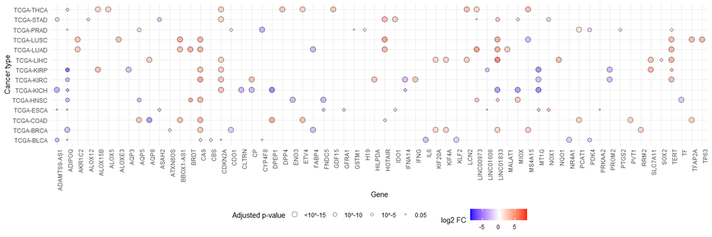

```r
plot_dgea(deseq.bbl.data.combined)
```

#### 3. Pyroptosis

Fetch the gene set of interest.

```r
genes <- read.csv(paste0(RCDdb, "Pyroptosis.csv"))
genes$gene_id <- cleanid(genes$gene_id)
genes <- distinct(genes, gene_id, .keep_all = TRUE)
genes <- subset(genes, gene_id != "")
genes
```

|  | deathtype | gene | description | gene_id | gene_biotype | pmid | comment |
| --- | --- | --- | --- | --- | --- | --- | --- |
| 1 | Pyroptosis | BAK1 | BCL2 antagonist/killer 1 | ENSG00000030110 | protein_coding | 35439536 | BAK1 is a protein that promotes cell apoptosis. The protein level of BAK1 in cells treated with BPA is significantly higher than that in the control group. The action of YVAD clearly shows that caspas… |
| 2 | Pyroptosis | BAX | BCL2 associated X, apoptosis regulator | ENSG00000087088 | protein_coding | 32332857 | Chemotherapy-induced pyroptosis in cancer cells is mediated by BAK/BAX-caspase-3-GSDME signaling pathway. |
| 3 | Pyroptosis | CASP1 | caspase 1 | ENSG00000137752 | protein_coding | 34531375 | PRMT5 can regulate cell pyroptosis in multiple myeloma by inhibiting the expression of CASP1. When PRMT5 expression is interfered, the expression of CASP1 is upregulated, thus promoting pyroptosis of … |
| 4 | Pyroptosis | CASP3 | caspase 3 | ENSG00000164305 | protein_coding | 33133646 | When GSDME is highly expressed, chemotherapeutic drugs can induce CASP3-dependent Pyroptosis, thereby shrinking tumors.CASP3 is a key protein that induces apoptosis and inflammatory cell death, which … |
| 5 | Pyroptosis | CASP4 | caspase 4 | ENSG00000196954 | protein_coding | 32109412 | Site-specific autoprocessing of Caspase-4/11 generates a p10 product that binds with high affinity to the GSDMD-C domain, facilitating cleavage of GSDMD and inducing Pyroptosis. Crystal structures of … |
| 6 | Pyroptosis | CASP5 | caspase 5 | ENSG00000137757 | protein_coding | 32109412 | CASP5 can generate a p10 product that binds with high affinity to the GSDMD-C (inhibitory domain of gasdermin D), facilitating cleavage of GSDMD and inducing Pyroptosis through site-specific autoproce… |
| 7 | Pyroptosis | CASP6 | caspase 6 | ENSG00000138794 | protein_coding | 32298652 | CASP6 promotes pyroptosis induced by IAV infection and CASP6 deficiency reduces the number of cell deaths during IAV infection . In addition, CASP6 also participates in the activation of other cell de… |
| 8 | Pyroptosis | CASP8 | caspase 8 | ENSG00000064012 | protein_coding | 31748744 | The expression of enzymatically inactive CASP8(C362S) triggered the formation of ASC specks, activation of caspase-1 and secretion of IL-1\xa6\xc2, resulting in pyroptosis. |
| 9 | Pyroptosis | CASP9 | caspase 9 | ENSG00000132906 | protein_coding | 27174943 | CASP9 does not seem to be directly related to Necroptosis.Injection of a CAS-9 inhibitor significantly inhibits high level CASP-1 activity in PI+/annexin V- (one of the characteristics of pyroptosis) … |
| 10 | Pyroptosis | SCAF11 | SR-related CTD associated factor 11 | ENSG00000139218 | protein_coding | 32109412 | CASP11 is involved in Pyroptosis by cleaving the Pyroptosis execution protein GSDMD to induce dimerization-mediated caspase activation and cleavage, and allowing the pore-forming domain of GSDMD to br… |

[output cut: 41 more lines]

Filter the genes to include only those in the gene set of interest, and then perform differential gene expression analysis.

```r
deseq.bbl.data.combined <- filter_gene_set_and_perform_dgea(genes)
```

```
[1] "TCGA-LUSC"
[1] "============="
```

```
[1] "TCGA-COAD"
[1] "============="
```

```
[1] "TCGA-KICH"
[1] "============="
```

```
[1] "TCGA-KIRC"
[1] "============="
```

```
[1] "TCGA-PRAD"
[1] "============="
```

```
[1] "TCGA-BRCA"
[1] "============="
```

```
[1] "TCGA-HNSC"
[1] "============="
```

```
[1] "TCGA-KIRP"
[1] "============="
```

```
[1] "TCGA-LIHC"
[1] "============="
```

```
[1] "TCGA-STAD"
[1] "============="
```

```
[1] "TCGA-THCA"
[1] "============="
```

```
[1] "TCGA-BLCA"
[1] "============="
```

```
[1] "TCGA-LUAD"
[1] "============="
```

```
[1] "TCGA-ESCA"
[1] "============="
```

```r
deseq.bbl.data.combined
```

|  | baseMean | log2FoldChange | lfcSE | stat | pvalue | padj | cancer_type | gene_symbol |
| --- | --- | --- | --- | --- | --- | --- | --- | --- |
| ENSG00000022556...1 | 1498.999176 | 1.944692 | 0.3820950 | 5.089552 | 3.589111e-07 | 9.152232e-07 | TCGA-LUSC | NLRP2 |
| ENSG00000073282...2 | 18360.759544 | 5.889908 | 0.2923929 | 20.143814 | 3.049244e-90 | 1.555115e-88 | TCGA-LUSC | TP63 |
| ENSG00000091106...3 | 622.439442 | -2.532828 | 0.1520195 | -16.661200 | 2.509370e-62 | 6.398893e-61 | TCGA-LUSC | NLRC4 |
| ENSG00000105928...4 | 1326.662265 | 1.634507 | 0.1901699 | 8.594982 | 8.327758e-18 | 3.861051e-17 | TCGA-LUSC | GSDME |
| ENSG00000136244...5 | 3112.200250 | -2.758132 | 0.3584102 | -7.695461 | 1.409847e-14 | 5.135870e-14 | TCGA-LUSC | IL6 |
| ENSG00000137757...6 | 60.733658 | -1.568921 | 0.1676245 | -9.359736 | 7.993586e-21 | 5.095911e-20 | TCGA-LUSC | CASP5 |
| ENSG00000147697...7 | 621.678291 | 3.979767 | 0.2518447 | 15.802466 | 2.991821e-56 | 5.086096e-55 | TCGA-LUSC | GSDMC |
| ENSG00000162711...8 | 568.222162 | -1.728666 | 0.2008701 | -8.605890 | 7.572700e-18 | 3.861051e-17 | TCGA-LUSC | NLRP3 |
| ENSG00000163568...9 | 355.519262 | 2.206947 | 0.2638731 | 8.363666 | 6.079872e-17 | 2.583945e-16 | TCGA-LUSC | AIM2 |
| ENSG00000167634...10 | 48.718911 | 2.690942 | 0.3369674 | 7.985765 | 1.396537e-15 | 5.478723e-15 | TCGA-LUSC | NLRP7 |

[output cut: 69 more lines]

Plot the results.

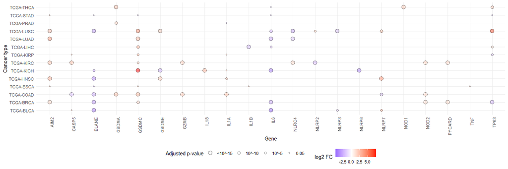

```r
plot_dgea(deseq.bbl.data.combined)
```

#### 4. Alkaliptosis

Fetch the gene set of interest.

```r
genes <- read.csv(paste0(RCDdb, "Alkaliptosis.csv"))
genes$gene_id <- cleanid(genes$gene_id)
genes <- distinct(genes, gene_id, .keep_all = TRUE)
genes <- subset(genes, gene_id != "")
genes
```

|  | deathtype | gene | description | gene_id | gene_biotype | pmid | comment |
| --- | --- | --- | --- | --- | --- | --- | --- |
| 1 | Alkaliptosis | IKBKB | inhibitor of nuclear factor kappa B kinase subunit beta | ENSG00000104365 | protein_coding | 31467365 | IKBKB is involved in the regulation of Alkaliptosis because the NF-\xa6\xcaB signaling pathway, which includes IKBKB, is found to contribute to Alkaliptosis regulation and the process. The NF-\xa6\xca… |
| 2 | Alkaliptosis | NFKB1 | nuclear factor kappa B subunit 1 | ENSG00000109320 | protein_coding | 31467365 | After the activation of the NF-\xa6\xcaB pathway, as a protective pathway for survival, it can fix free radicals such as active oxygen and maintain the stability of the cell environment to reduce cell… |
| 3 | Alkaliptosis | CA9 | carbonic anhydrase 9 | ENSG00000107159 | protein_coding | 31467365 | CA9 is identified as a key negative regulator in Alkaliptosis. CA9, which is activated by the NF-\xa6\xcaB pathway, is thought to be a negatively regulated gene responsible for inhibiting intracellula… |
| 4 | Alkaliptosis | CHUK | component of inhibitor of nuclear factor kappa B kinase complex | ENSG00000213341 | protein_coding | 31467365 | CHUK is related to Alkaliptosis, inducing the release of lactate dehydrogenase and intracellular alkalinization through activating the NF-\xa6\xcaB pathway, leading to cell death. |
| 5 | Alkaliptosis | IKBKG | inhibitor of nuclear factor kappa B kinase regulatory subunit gamma | ENSG00000269335 | protein_coding | 31467365 | IKBKG was found to activate the NF-\xa6\xcaB pathway by disrupting the function of NFKBIA, leading to the release of NF-\xa6\xcaB and subsequent activation of the NF-\xa6\xcaB pathway. Moreover, NF-\x… |
| 6 | Alkaliptosis | RELA | RELA proto-oncogene, NF-kB subunit | ENSG00000173039 | protein_coding | 31467365 | RELA is identified as a transcription factor that mediates the NF-\xa6\xcaB pathway by activating the IKK protein complex, phosphorylating and degrading NFKBIA, and regulating the expression of many g… |
| 7 | Alkaliptosis | FN1 | fibronectin 1 | ENSG00000115414 | protein_coding | 33670487 | The study used an in-silico approach to identify potential drug targets and non-apoptotic cell death-related genes in colon adenocarcinoma, glioblastoma multiforme, and small cell lung cancer, three t… |
| 8 | Alkaliptosis | AGER | advanced glycosylation end-product specific receptor | ENSG00000204305 | protein_coding | 33992959 | AGER participates in Alkaliptosis by binding to HMGB1, leading to the activation of the STING1 pathway and the production of inflammation. Specifically, when the released HMGB1 from Alkaliptotic cells… |
| 9 | Alkaliptosis | HMGB1 | high mobility group box 1 | ENSG00000189403 | protein_coding | 33992959 | During Alkaliptosis, HMGB1 translocates and is released from the nucleus to the cytoplasm and extracellular space, promoting the resulting inflammation. Among the damage-associated molecular patterns … |
| 10 | Alkaliptosis | STING1 | stimulator of interferon response cGAMP interactor 1 | ENSG00000184584 | protein_coding | 33992959 | STING1 is involved in the release of HMGB1 and the production of cytokines after cell death. Once Alkaliptotic cancer cells release HMGB1, extracellular HMGB1 binds to macrophages through the STING1 p… |

[output cut: 5 more lines]

Filter the genes to include only those in the gene set of interest, and then perform differential gene expression analysis.

```r
deseq.bbl.data.combined <- filter_gene_set_and_perform_dgea(genes)
```

```
[1] "TCGA-LUSC"
[1] "============="
```

```
[1] "TCGA-COAD"
[1] "============="
```

```
[1] "TCGA-KICH"
[1] "============="
```

```
[1] "TCGA-KIRC"
[1] "============="
```

```
[1] "TCGA-PRAD"
[1] "============="
```

```
[1] "TCGA-BRCA"
[1] "============="
```

```
[1] "TCGA-HNSC"
[1] "============="
```

```
[1] "TCGA-KIRP"
[1] "============="
```

```
[1] "TCGA-LIHC"
[1] "============="
```

```
[1] "TCGA-STAD"
[1] "============="
```

```
[1] "TCGA-THCA"
[1] "============="
```

```
[1] "TCGA-BLCA"
[1] "============="
```

```
[1] "TCGA-LUAD"
[1] "============="
```

```
[1] "TCGA-ESCA"
[1] "============="
```

```r
deseq.bbl.data.combined
```

|  | baseMean | log2FoldChange | lfcSE | stat | pvalue | padj | cancer_type | gene_symbol |
| --- | --- | --- | --- | --- | --- | --- | --- | --- |
| ENSG00000086991...1 | 3.363078e+02 | 1.837009 | 0.2091713 | 8.782318 | 1.601397e-18 | 6.005238e-18 | TCGA-LUSC | NOX4 |
| ENSG00000107159...2 | 2.019336e+03 | 6.532922 | 0.4104513 | 15.916436 | 4.873570e-57 | 2.436785e-56 | TCGA-LUSC | CA9 |
| ENSG00000144554...3 | 9.583893e+02 | 2.435309 | 0.1390608 | 17.512556 | 1.149159e-68 | 1.723739e-67 | TCGA-LUSC | FANCD2 |
| ENSG00000204305...4 | 5.933749e+04 | -5.511228 | 0.3284051 | -16.781796 | 3.316534e-63 | 2.487400e-62 | TCGA-LUSC | AGER |
| ENSG00000086991...5 | 7.460741e+01 | 3.419779 | 0.3247460 | 10.530628 | 6.241688e-26 | 4.681266e-25 | TCGA-COAD | NOX4 |
| ENSG00000107159...6 | 1.116850e+03 | 5.664061 | 0.3625088 | 15.624617 | 4.948846e-55 | 7.423269e-54 | TCGA-COAD | CA9 |
| ENSG00000107159...7 | 7.454813e+00 | -2.569759 | 0.7389237 | -3.477706 | 5.057237e-04 | 1.264309e-03 | TCGA-KICH | CA9 |
| ENSG00000086991...8 | 4.176917e+03 | -1.618432 | 0.2412008 | -6.709897 | 1.947620e-11 | 3.651787e-11 | TCGA-KIRC | NOX4 |
| ENSG00000107159...9 | 6.505011e+03 | 6.993434 | 0.3237005 | 21.604645 | 1.624321e-103 | 2.436482e-102 | TCGA-KIRC | CA9 |
| ENSG00000115414...10 | 7.708634e+04 | 1.685019 | 0.1492522 | 11.289745 | 1.474645e-29 | 5.570507e-29 | TCGA-KIRC | FN1 |

[output cut: 24 more lines]

Plot the results.

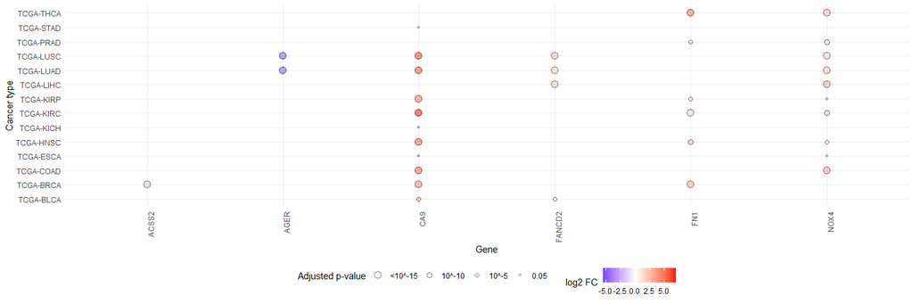

```r
plot_dgea(deseq.bbl.data.combined)
```

#### 5. Apoptosis

Fetch the gene set of interest.

```r
genes <- read.csv(paste0(RCDdb, "Apoptosis.csv"))
genes$gene_id <- cleanid(genes$gene_id)
genes <- distinct(genes, gene_id, .keep_all = TRUE)
genes <- subset(genes, gene_id != "")
genes
```

|  | deathtype | gene | description | gene_id | gene_biotype | pmid | comment |
| --- | --- | --- | --- | --- | --- | --- | --- |
| 1 | Apoptosis | AATF | apoptosis antagonizing transcription factor | ENSG00000275700 | protein_coding | 29321668 | AATF is involved in the regulation of apoptosis by inhibiting p53-driven apoptosis and modulating cellular outcome of the DDR signaling pathway. It is a p53 regulator that affects the transcription of… |
| 2 | Apoptosis | ABL1 | ABL proto-oncogene 1, non-receptor tyrosine kinase | ENSG00000097007 | protein_coding | 31311809 | BCR-ABL1 is a kinase that phosphorylates PDK1 in the PI3K/AKT pathway. The phosphorylation of PDK1 is essential for maintaining AKT activity and subsequently, sustaining BCR-ABL1 cell survival signals… |
| 3 | Apoptosis | ACAA2 | acetyl-CoA acyltransferase 2 | ENSG00000167315 | protein_coding | 29323178 | ACAA2 participates in cellular biological processes by regulating cell apoptosis. Overexpression of ACAA2 can induce cell apoptosis, while shRNA interference can inhibit this process. |
| 4 | Apoptosis | ACKR3 | atypical chemokine receptor 3 | ENSG00000144476 | protein_coding | 33868792 | Through single-cell RNA sequencing, it was found that there were changes in the expression levels of ACKR3 and other genes before and after PD-1 targeted therapy, including EGFR, AREG, WNT5A, PTPRK, G… |
| 5 | Apoptosis | ACVR1 | activin A receptor type 1 | ENSG00000115170 | protein_coding | 28459464 | ACVR1 is related to Apoptosis in this paper and it is a crucial member of the bone morphogenetic protein (BMP) signaling pathway that induces apoptosis of patient-derived glioma-initiating cells (GICs… |
| 6 | Apoptosis | ACVR1B | activin A receptor type 1B | ENSG00000135503 | protein_coding | 37020544 | ACVR1B participates in regulating immune cell apoptosis, thus helping to eliminate infected cells and reduce pathogen burden. An increase in ACVR1B mRNA levels has been observed through large-scale co… |
| 7 | Apoptosis | ADORA1 | adenosine A1 receptor | ENSG00000163485 | protein_coding | 33961854 | Overexpression of ADORA1 decreases cleaved Caspase-3 and PARP expression, leading to reduced NPC cell apoptosis. Conversely, ADORA1 knockdown increases TRAIL-induced apoptosis sensitivity, resulting i… |
| 8 | Apoptosis | AEN | apoptosis enhancing nuclease | ENSG00000181026 | protein_coding | 18264133 | AEN was found to be a direct target gene of p53 and an important downstream mediator of p53 in inducing apoptosis in this article. AEN is a typical exonuclease containing three conserved exonuclease d… |
| 9 | Apoptosis | AGT | angiotensinogen | ENSG00000135744 | protein_coding | 14997208 | The components of the renin _ angiotensin system (RAS) may be involved in cell growth and survival.Angiotensinogen (AGT) was shown to inhibit vascular cell growth and angiogenesisHuman glioblastoma ce… |
| 10 | Apoptosis | AGTR2 | angiotensin II receptor type 2 | ENSG00000180772 | protein_coding | 15221785 | The frequency of a TAATGC haplotype significantly increased in preeclampsia patients, which includes nucleotides g.1701, g.2041, g.2184, g.4673, g.4679 and g.4975. This haplotype may lead to overexpre… |

[output cut: 598 more lines]

Filter the genes to include only those in the gene set of interest, and then perform differential gene expression analysis.

```r
deseq.bbl.data.combined <- filter_gene_set_and_perform_dgea(genes)
```

```
[1] "TCGA-LUSC"
[1] "============="
```

```
[1] "TCGA-COAD"
[1] "============="
```

```
[1] "TCGA-KICH"
[1] "============="
```

```
[1] "TCGA-KIRC"
[1] "============="
```

```
[1] "TCGA-PRAD"
[1] "============="
```

```
[1] "TCGA-BRCA"
[1] "============="
```

```
[1] "TCGA-HNSC"
[1] "============="
```

```
[1] "TCGA-KIRP"
[1] "============="
```

```
[1] "TCGA-LIHC"
[1] "============="
```

```
[1] "TCGA-STAD"
[1] "============="
```

```
[1] "TCGA-THCA"
[1] "============="
```

```
[1] "TCGA-BLCA"
[1] "============="
```

```
[1] "TCGA-LUAD"
[1] "============="
```

```
[1] "TCGA-ESCA"
[1] "============="
```

```r
deseq.bbl.data.combined
```

|  | baseMean | log2FoldChange | lfcSE | stat | pvalue | padj | cancer_type | gene_symbol |
| --- | --- | --- | --- | --- | --- | --- | --- | --- |
| ENSG00000006625...1 | 1.199223e+03 | 1.927894 | 0.12373330 | 15.581044 | 9.794191e-55 | 4.799153e-53 | TCGA-LUSC | GGCT |
| ENSG00000007968...2 | 5.029424e+02 | 2.959788 | 0.17667638 | 16.752596 | 5.420847e-63 | 4.553512e-61 | TCGA-LUSC | E2F2 |
| ENSG00000008735...3 | 6.699454e+02 | 2.333066 | 0.23572513 | 9.897400 | 4.272392e-23 | 2.347819e-22 | TCGA-LUSC | MAPK8IP2 |
| ENSG00000010671...4 | 1.524666e+03 | -2.146023 | 0.17960638 | -11.948477 | 6.612617e-33 | 6.480364e-32 | TCGA-LUSC | BTK |
| ENSG00000011600...5 | 8.856787e+03 | -1.846259 | 0.19016273 | -9.708837 | 2.764726e-22 | 1.464558e-21 | TCGA-LUSC | TYROBP |
| ENSG00000012048...6 | 1.180144e+03 | 2.195513 | 0.12702807 | 17.283685 | 6.242910e-67 | 7.341662e-65 | TCGA-LUSC | BRCA1 |
| ENSG00000019549...7 | 2.182775e+03 | 2.033700 | 0.17709406 | 11.483730 | 1.592591e-30 | 1.318935e-29 | TCGA-LUSC | SNAI2 |
| ENSG00000019582...8 | 2.788321e+05 | -1.630986 | 0.18582078 | -8.777201 | 1.675929e-18 | 6.749632e-18 | TCGA-LUSC | CD74 |
| ENSG00000019991...9 | 1.295708e+03 | -2.088145 | 0.20916972 | -9.983020 | 1.808769e-23 | 1.032579e-22 | TCGA-LUSC | HGF |
| ENSG00000022556...10 | 1.468816e+03 | 1.820039 | 0.38777282 | 4.693569 | 2.684789e-06 | 4.684439e-06 | TCGA-LUSC | NLRP2 |

[output cut: 966 more lines]

Plot the results.

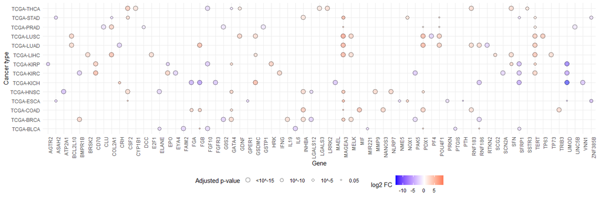

```r
plot_dgea(deseq.bbl.data.combined)
```

#### 6. Autophagy-Dependent Cell Death

Fetch the gene set of interest.

```r
genes <- read.csv(paste0(RCDdb, "Autophagy_dependent_cell_death.csv"))
genes$gene_id <- cleanid(genes$gene_id)
genes <- distinct(genes, gene_id, .keep_all = TRUE)
genes <- subset(genes, gene_id != "")
genes
```

|  | deathtype | gene | description | gene_id | gene_biotype | pmid | comment |
| --- | --- | --- | --- | --- | --- | --- | --- |
| 1 | Autophagy_dependent_cell_death | ABHD5 | abhydrolase domain containing 5, lysophosphatidic acid acyltransferase | ENSG00000011198 | protein_coding | 25315780 | increased activity of ABHD5 increases autophagy of cells,autophagy of mitochondria;increased activity of ABHD5 increases autophagy by muscle cell lines |
| 2 | Autophagy_dependent_cell_death | ABL1 | ABL proto-oncogene 1, non-receptor tyrosine kinase | ENSG00000097007 | protein_coding | 20841568 | increased activity of ABL1 affects autophagy |
| 3 | Autophagy_dependent_cell_death | ABL2 | ABL proto-oncogene 2, non-receptor tyrosine kinase | ENSG00000143322 | protein_coding | 20841568 | increased activity of ABL2 affects autophagy |
| 4 | Autophagy_dependent_cell_death | ACBD5 | acyl-CoA binding domain containing 5 | ENSG00000107897 | protein_coding | 24535825 | increased activity of ACBD5 increases autophagy of peroxisomes |
| 5 | Autophagy_dependent_cell_death | ACLY | ATP citrate lyase | ENSG00000131473 | protein_coding | 24560926 | decreased activity of ACLY increases autophagy |
| 6 | Autophagy_dependent_cell_death | ACP2 | acid phosphatase 2, lysosomal | ENSG00000134575 | protein_coding | 18690537 | increased activity of ACP2 affects autophagic cell death |
| 7 | Autophagy_dependent_cell_death | ACSL1 | acyl-CoA synthetase long chain family member 1 | ENSG00000151726 | protein_coding | 26220174 | decreased activity of ACSL1 decreases autophagy |
| 8 | Autophagy_dependent_cell_death | ADIPOQ | adiponectin, C1Q and collagen domain containing | ENSG00000181092 | protein_coding | 23894332 | increased activity of ADIPOQ decreases autophagy of ventricular myocytes;decreased activity of ADIPOQ increases autophagy of cardiomyocytes |
| 9 | Autophagy_dependent_cell_death | AGT | angiotensinogen | ENSG00000135744 | protein_coding | 19433781 | increased activity of AGT increases autophagy of cardiomyocytes |
| 10 | Autophagy_dependent_cell_death | AGER | advanced glycosylation end-product specific receptor | ENSG00000204305 | protein_coding | 22509024 | decreased activity of AGER decreases autophagy of pancreatic cancer cell lines;decreased activity of AGER decreases autophagy |

[output cut: 863 more lines]

Filter the genes to include only those in the gene set of interest, and then perform differential gene expression analysis.

```r
deseq.bbl.data.combined <- filter_gene_set_and_perform_dgea(genes)
```

```
[1] "TCGA-LUSC"
[1] "============="
```

```
[1] "TCGA-COAD"
[1] "============="
```

```
[1] "TCGA-KICH"
[1] "============="
```

```
[1] "TCGA-KIRC"
[1] "============="
```

```
[1] "TCGA-PRAD"
[1] "============="
```

```
[1] "TCGA-BRCA"
[1] "============="
```

```
[1] "TCGA-HNSC"
[1] "============="
```

```
[1] "TCGA-KIRP"
[1] "============="
```

```
[1] "TCGA-LIHC"
[1] "============="
```

```
[1] "TCGA-STAD"
[1] "============="
```

```
[1] "TCGA-THCA"
[1] "============="
```

```
[1] "TCGA-BLCA"
[1] "============="
```

```
[1] "TCGA-LUAD"
[1] "============="
```

```
[1] "TCGA-ESCA"
[1] "============="
```

```r
deseq.bbl.data.combined
```

|  | baseMean | log2FoldChange | lfcSE | stat | pvalue | padj | cancer_type | gene_symbol |
| --- | --- | --- | --- | --- | --- | --- | --- | --- |
| ENSG00000004799...1 | 7.402419e+03 | -3.513707 | 0.27699293 | -12.685185 | 7.144471e-37 | 1.122703e-35 | TCGA-LUSC | PDK4 |
| ENSG00000012048...2 | 1.214872e+03 | 2.322737 | 0.12541289 | 18.520721 | 1.405422e-76 | 1.352719e-74 | TCGA-LUSC | BRCA1 |
| ENSG00000019991...3 | 1.259508e+03 | -1.993095 | 0.20510415 | -9.717479 | 2.539907e-22 | 1.862598e-21 | TCGA-LUSC | HGF |
| ENSG00000035664...4 | 2.213488e+03 | -2.373346 | 0.19570869 | -12.126931 | 7.604644e-34 | 1.045639e-32 | TCGA-LUSC | DAPK2 |
| ENSG00000067225...5 | 9.136497e+04 | 1.558879 | 0.09618702 | 16.206753 | 4.518146e-59 | 2.174358e-57 | TCGA-LUSC | PKM |
| ENSG00000073282...6 | 1.796262e+04 | 5.848518 | 0.28790205 | 20.314263 | 9.618248e-92 | 1.234342e-89 | TCGA-LUSC | TP63 |
| ENSG00000075651 | 3.638149e+03 | 2.497503 | 0.18223245 | 13.705042 | 9.471189e-43 | 1.971031e-41 | TCGA-LUSC | PLD1 |
| ENSG00000078081...8 | 2.413802e+04 | -2.723158 | 0.19771841 | -13.772908 | 3.709731e-43 | 7.934703e-42 | TCGA-LUSC | LAMP3 |
| ENSG00000078900...9 | 1.115051e+03 | 2.496861 | 0.26650729 | 9.368830 | 7.334115e-21 | 4.411929e-20 | TCGA-LUSC | TP73 |
| ENSG00000079337...10 | 9.468379e+02 | -1.742659 | 0.15058406 | -11.572664 | 5.669463e-31 | 6.236410e-30 | TCGA-LUSC | RAPGEF3 |

[output cut: 990 more lines]

Plot the results.

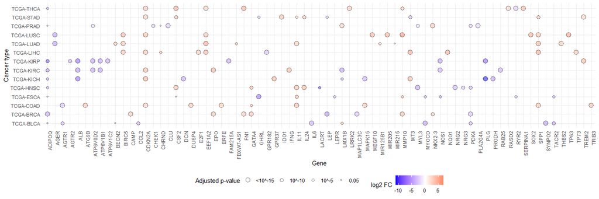

```r
plot_dgea(deseq.bbl.data.combined)
```

#### 7. Cuproptosis

Fetch the gene set of interest.

```r
genes <- read.csv(paste0(RCDdb, "Cuproptosis.csv"))
genes$gene_id <- cleanid(genes$gene_id)
genes <- distinct(genes, gene_id, .keep_all = TRUE)
genes <- subset(genes, gene_id != "")
genes
```

|  | deathtype | gene | description | gene_id | gene_biotype | pmid | comment |
| --- | --- | --- | --- | --- | --- | --- | --- |
| 1 | Cuproptosis | MTF1 | metal regulatory transcription factor 1 | ENSG00000188786 | protein_coding | 35298263 | Negative hits. To identify the specific metabolic pathways that mediate copper toxicity, we performed genome-wide CRISPR-Cas9 loss-of-function screens to identify the genes involved in copper ionophor… |
| 2 | Cuproptosis | GLS | glutaminase | ENSG00000115419 | protein_coding | 35298263 | Negative hits. To identify the specific metabolic pathways that mediate copper toxicity, we performed genome-wide CRISPR-Cas9 loss-of-function screens to identify the genes involved in copper ionophor… |
| 3 | Cuproptosis | CDKN2A | cyclin dependent kinase inhibitor 2A | ENSG00000147889 | protein_coding | 35298263 | Negative hits. To identify the specific metabolic pathways that mediate copper toxicity, we performed genome-wide CRISPR-Cas9 loss-of-function screens to identify the genes involved in copper ionophor… |
| 4 | Cuproptosis | DNA2 | DNA replication helicase/nuclease 2 | ENSG00000138346 | protein_coding | 35298263 | Mass spectrometric analysis also revealed that copper ionophore treatment leads to loss of Fe-S cluster proteins (Fig. 6, A and B) in an FDX1-dependent manner (Fig. 6C) as well as the induction of pro… |
| 5 | Cuproptosis | NTHL1 | nth like DNA glycosylase 1 | ENSG00000065057 | protein_coding | 35298263 | Mass spectrometric analysis also revealed that copper ionophore treatment leads to loss of Fe-S cluster proteins (Fig. 6, A and B) in an FDX1-dependent manner (Fig. 6C) as well as the induction of pro… |
| 6 | Cuproptosis | POLE | DNA polymerase epsilon, catalytic subunit | ENSG00000177084 | protein_coding | 35298263 | Mass spectrometric analysis also revealed that copper ionophore treatment leads to loss of Fe-S cluster proteins (Fig. 6, A and B) in an FDX1-dependent manner (Fig. 6C) as well as the induction of pro… |
| 7 | Cuproptosis | POLD1 | DNA polymerase delta 1, catalytic subunit | ENSG00000062822 | protein_coding | 35298263 | Mass spectrometric analysis also revealed that copper ionophore treatment leads to loss of Fe-S cluster proteins (Fig. 6, A and B) in an FDX1-dependent manner (Fig. 6C) as well as the induction of pro… |
| 8 | Cuproptosis | CISD1 | CDGSH iron sulfur domain 1 | ENSG00000122873 | protein_coding | 35298263 | Mass spectrometric analysis also revealed that copper ionophore treatment leads to loss of Fe-S cluster proteins (Fig. 6, A and B) in an FDX1-dependent manner (Fig. 6C) as well as the induction of pro… |
| 9 | Cuproptosis | GLRX5 | glutaredoxin 5 | ENSG00000182512 | protein_coding | 35298263 | Mass spectrometric analysis also revealed that copper ionophore treatment leads to loss of Fe-S cluster proteins (Fig. 6, A and B) in an FDX1-dependent manner (Fig. 6C) as well as the induction of pro… |
| 10 | Cuproptosis | PPAT | phosphoribosyl pyrophosphate amidotransferase | ENSG00000128059 | protein_coding | 35298263 | Mass spectrometric analysis also revealed that copper ionophore treatment leads to loss of Fe-S cluster proteins (Fig. 6, A and B) in an FDX1-dependent manner (Fig. 6C) as well as the induction of pro… |

[output cut: 17 more lines]

Filter the genes to include only those in the gene set of interest, and then perform differential gene expression analysis.

```r
deseq.bbl.data.combined <- filter_gene_set_and_perform_dgea(genes)
```

```
[1] "TCGA-LUSC"
[1] "============="
```

```
[1] "TCGA-COAD"
[1] "============="
```

```
[1] "TCGA-KICH"
[1] "============="
```

```
[1] "TCGA-KIRC"
[1] "============="
```

```
[1] "TCGA-PRAD"
[1] "============="
```

```
[1] "TCGA-BRCA"
[1] "============="
```

```
[1] "TCGA-HNSC"
[1] "============="
```

```
[1] "TCGA-KIRP"
[1] "============="
```

```
[1] "TCGA-LIHC"
[1] "============="
```

```
[1] "TCGA-STAD"
[1] "============="
```

```
[1] "TCGA-THCA"
[1] "============="
```

```
[1] "TCGA-BLCA"
[1] "============="
```

```
[1] "TCGA-LUAD"
[1] "============="
```

```
[1] "TCGA-ESCA"
[1] "============="
```

```r
deseq.bbl.data.combined
```

|  | baseMean | log2FoldChange | lfcSE | stat | pvalue | padj | cancer_type | gene_symbol |
| --- | --- | --- | --- | --- | --- | --- | --- | --- |
| ENSG00000128059...1 | 931.16108 | 1.892814 | 0.11025835 | 17.167078 | 4.684117e-66 | 1.264712e-64 | TCGA-LUSC | PPAT |
| ENSG00000138346...2 | 409.82312 | 2.167735 | 0.13713086 | 15.807782 | 2.749788e-56 | 3.712214e-55 | TCGA-LUSC | DNA2 |
| ENSG00000147889...3 | 1113.59310 | 3.981482 | 0.29145279 | 13.660812 | 1.740333e-42 | 1.566300e-41 | TCGA-LUSC | CDKN2A |
| ENSG00000065057 | 1458.87901 | 1.596552 | 0.19605906 | 8.143218 | 3.849096e-16 | 1.299070e-15 | TCGA-COAD | NTHL1 |
| ENSG00000128059...5 | 681.07931 | 1.619027 | 0.12002419 | 13.489170 | 1.811289e-41 | 2.445240e-40 | TCGA-COAD | PPAT |
| ENSG00000147889...6 | 212.44744 | 3.293117 | 0.27235316 | 12.091348 | 1.173451e-33 | 1.056106e-32 | TCGA-COAD | CDKN2A |
| ENSG00000171503 | 1530.77988 | -2.013207 | 0.09546767 | -21.087846 | 1.028379e-98 | 2.776625e-97 | TCGA-COAD | ETFDH |
| ENSG00000258366...8 | 29.41345 | 1.736531 | 0.19958671 | 8.700633 | 3.300386e-18 | 1.273006e-17 | TCGA-COAD | RTEL1 |
| ENSG00000115419 | 14919.35917 | -1.692766 | 0.18360177 | -9.219772 | 2.977338e-20 | 4.019407e-19 | TCGA-KICH | GLS |
| ENSG00000147889...10 | 328.16139 | 4.791835 | 0.45387112 | 10.557699 | 4.679921e-26 | 1.263579e-24 | TCGA-KICH | CDKN2A |

[output cut: 17 more lines]

Plot the results.

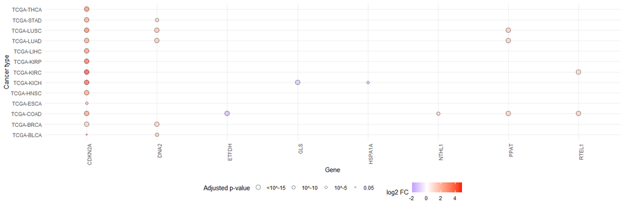

```r
plot_dgea(deseq.bbl.data.combined)
```

#### 8. Disulfidptosis

Fetch the gene set of interest.

```r
genes <- read.csv(paste0(RCDdb, "Disulfidptosis.csv"))
genes$gene_id <- cleanid(genes$gene_id)
genes <- distinct(genes, gene_id, .keep_all = TRUE)
genes <- subset(genes, gene_id != "")
genes
```

|  | deathtype | gene | description | gene_id | gene_biotype | pmid | comment |
| --- | --- | --- | --- | --- | --- | --- | --- |
| 1 | Disulfidptosis | FLNA | filamin A | ENSG00000196924 | protein_coding | 36747082 | FLNA participates in disulfidptosis by mediating the collapse of F-actin in response to intracellular disulfide stress induced by glucose starvation in SLC7A11high cells. This leads to the formation o… |
| 2 | Disulfidptosis | FLNB | filamin B | ENSG00000136068 | protein_coding | 36747082 | Abnormal accumulation of intracellular disulfides leads to abnormal disulfide bonding in the intracellular actin backbone, the formation of disulfide fusion complexes, and ultimately cell death. |
| 3 | Disulfidptosis | MYH9 | myosin heavy chain 9 | ENSG00000100345 | protein_coding | 36747082 | MYH9 is involved in disulfidptosis through the formation of aberrant disulfide bonds in actin cytoskeleton proteins. |
| 4 | Disulfidptosis | TLN1 | talin 1 | ENSG00000137076 | protein_coding | 36747082 | TLN1 participates in disulfidptosis by forming aberrant disulfide bonds in actin cytoskeleton proteins and undergoing F-actin collapse. |
| 5 | Disulfidptosis | ACTB | actin beta | ENSG00000075624 | protein_coding | 36747082 | In cells with high SLC7A11 expression, glucose starvation induces abnormal cysteine bonds to bind to the actin skeleton protein, and F-actin collapses, leading to disulfidptosis. |
| 6 | Disulfidptosis | MYL6 | myosin light chain 6 | ENSG00000092841 | protein_coding | 36747082 | Experimental results indicate that glucose starvation leads to abnormal disulfide bonding in actin cytoskeleton proteins including MYL6 in SLC7A11high cells, which is involved in disulfidptosis. |
| 7 | Disulfidptosis | MYH10 | myosin heavy chain 10 | ENSG00000133026 | protein_coding | 36747082 | MYH10 Blots show that in UMRC6 cells with high SLC7A11 expression, glucose starvation induces cell death by leading to F-actin collapse and abnormal disulfide bond formation. |
| 8 | Disulfidptosis | CAPZB | capping actin protein of muscle Z-line subunit beta | ENSG00000077549 | protein_coding | 36747082 | GLUT inhibitors induce disulfidptosis in SLC7A11high tumor cells, leading to abnormal oxidative and depolymerization of CAPZB, which disrupts the stability of actin filaments. |
| 9 | Disulfidptosis | DSTN | destrin, actin depolymerizing factor | ENSG00000125868 | protein_coding | 36747082 | DSTN is an actin filament-cutting protein involved in cytoskeletal remodeling and cell migration. DSTN plays a role in the formation of disulfide bonds in actin cytoskeletal proteins. |
| 10 | Disulfidptosis | IQGAP1 | IQ motif containing GTPase activating protein 1 | ENSG00000140575 | protein_coding | 36747082 | IQGAP1 was found to be involved in disulfidptosis through its interaction with the actin cytoskeleton. Specifically, IQGAP1 was shown to promote the formation of lamellipodia and actin cytoskeleton po… |

[output cut: 6 more lines]

Filter the genes to include only those in the gene set of interest, and then perform differential gene expression analysis.

```r
deseq.bbl.data.combined <- filter_gene_set_and_perform_dgea(genes)
```

```
[1] "TCGA-LUSC"
[1] "============="
```

```
[1] "TCGA-COAD"
[1] "============="
```

```
[1] "TCGA-KICH"
[1] "============="
```

```
[1] "TCGA-KIRC"
[1] "============="
```

```
[1] "TCGA-PRAD"
[1] "============="
```

```
[1] "TCGA-BRCA"
[1] "============="
```

```
[1] "TCGA-HNSC"
[1] "============="
```

```
[1] "TCGA-KIRP"
[1] "============="
```

```
[1] "TCGA-LIHC"
[1] "============="
```

```
[1] "TCGA-STAD"
[1] "============="
```

```
[1] "TCGA-THCA"
[1] "============="
```

```
[1] "TCGA-BLCA"
[1] "============="
```

```
[1] "TCGA-LUAD"
[1] "============="
```

```
[1] "TCGA-ESCA"
[1] "============="
```

```r
deseq.bbl.data.combined
```

|  | baseMean | log2FoldChange | lfcSE | stat | pvalue | padj | cancer_type | gene_symbol |
| --- | --- | --- | --- | --- | --- | --- | --- | --- |
| ENSG00000151012...1 | 2868.5858 | 4.309019 | 0.31146554 | 13.834658 | 1.574843e-43 | 2.519749e-42 | TCGA-LUSC | SLC7A11 |
| ENSG00000151012...2 | 780.7884 | 3.457607 | 0.26664760 | 12.966952 | 1.883727e-38 | 3.013964e-37 | TCGA-COAD | SLC7A11 |
| ENSG00000151012...3 | 446.3980 | 4.636729 | 0.33958602 | 13.654063 | 1.909287e-42 | 3.054859e-41 | TCGA-KICH | SLC7A11 |
| ENSG00000107438 | 8108.3072 | 1.714109 | 0.09633815 | 17.792629 | 8.060759e-71 | 1.289721e-69 | TCGA-KIRC | PDLIM1 |
| ENSG00000133026 | 10816.5172 | -1.836580 | 0.11035885 | -16.641891 | 3.465006e-62 | 2.772005e-61 | TCGA-KIRC | MYH10 |
| ENSG00000151012...6 | 139.8623 | 1.772078 | 0.20854355 | 8.497400 | 1.938839e-17 | 7.755357e-17 | TCGA-KIRC | SLC7A11 |
| ENSG00000151012...7 | 530.1119 | 1.818776 | 0.22424760 | 8.110573 | 5.038176e-16 | 8.061081e-15 | TCGA-PRAD | SLC7A11 |
| ENSG00000151012...8 | 373.2790 | 2.243788 | 0.17331674 | 12.946171 | 2.469696e-38 | 3.951514e-37 | TCGA-BRCA | SLC7A11 |
| ENSG00000151012...9 | 2461.1711 | 2.123059 | 0.33564353 | 6.325338 | 2.526789e-10 | 8.085725e-10 | TCGA-HNSC | SLC7A11 |
| ENSG00000151012...10 | 631.7188 | 5.575285 | 0.45851000 | 12.159572 | 5.102530e-34 | 8.164048e-33 | TCGA-KIRP | SLC7A11 |

[output cut: 8 more lines]

Plot the results.

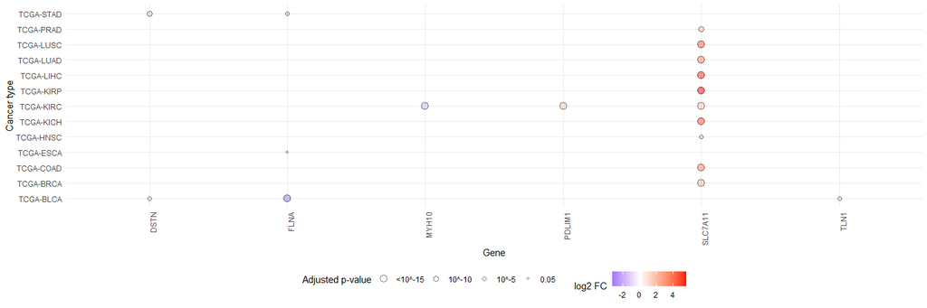

```r
plot_dgea(deseq.bbl.data.combined)
```

#### 9. Entotic Cell Death

Fetch the gene set of interest.

```r
genes <- read.csv(paste0(RCDdb, "Entotic_cell_death.csv"))
genes$gene_id <- cleanid(genes$gene_id)
genes <- distinct(genes, gene_id, .keep_all = TRUE)
genes <- subset(genes, gene_id != "")
genes
```

|  | deathtype | gene | description | gene_id | gene_biotype | pmid | comment |
| --- | --- | --- | --- | --- | --- | --- | --- |
| 1 | Entotic_cell_death | PRKAA1 | protein kinase AMP-activated catalytic subunit alpha 1 | ENSG00000132356 | protein_coding | 28683313 | It has recently been demonstrated that, in conditions of glucose withdrawal, cells displaying high 5\xa1\xe4 AMP-activated protein kinase (AMPK) activity succumb to entosis, underscoring a possible fu… |
| 2 | Entotic_cell_death | ATG5 | autophagy related 5 | ENSG00000057663 | protein_coding | 22002674 | The research found that ATG5, along with other autophagy proteins such as ATG7, played a critical role in Entotic cell death. When the expression of ATG5 was inhibited, the death of internalized cells… |
| 3 | Entotic_cell_death | ATG7 | autophagy related 7 | ENSG00000197548 | protein_coding | 22002674 | ATG7, an autophagy protein, is essential for facilitating lysosome fusion with single-membrane vacuoles, including entotic vacuoles, and the successful degradation of their internalized cargo. In the … |
| 4 | Entotic_cell_death | BECN1 | beclin 1 | ENSG00000126581 | protein_coding | 29362479 | Along similar lines, abolishing autophagy by pharmacological means or by genetically depleting_TG5_r_ECN1, prevents the neurotoxicity of cocaine in cultured neurons |
| 5 | Entotic_cell_death | CDC42 | cell division cycle 42 | ENSG00000070831 | protein_coding | 28693721 | The existence of a specific form of entosis occurring in cancer cells during mitosis (entotic mitosis), which is driven by aberrant mitotic rounding (and thus reduced adhesion) in conditions of cell d… |
| 6 | Entotic_cell_death | CDH1 | cadherin 1 | ENSG00000039068 | protein_coding | 18045538 | The uptake of entotic cells is an integrin-independent process promoted by the formation of junctions between engulfing and entotic cells that involve the adhesion proteins cadherin 1 (CDH1; also know… |
| 7 | Entotic_cell_death | CTNNA1 | catenin alpha 1 | ENSG00000044115 | protein_coding | 26192076 | The uptake of entotic cells is an integrin-independent process promoted by the formation of junctions between engulfing and entotic cells that involve the adhesion proteins cadherin 1 (CDH1; also know… |
| 8 | Entotic_cell_death | CYBB | cytochrome b-245 beta chain | ENSG00000165168 | protein_coding | 28847720 | LAP bridges phagocytosis and autophagy; this process is regulated by the core LC3 lipidation machinery (e.g., ATG5, ATG7, class III phosphatidylinositol 3-kinase complex [e.g., phosphatidylinositol 3-… |
| 9 | Entotic_cell_death | MYH14 | myosin heavy chain 14 | ENSG00000105357 | protein_coding | 35265203 | The actin heavy chain encoded by MYH14 is a subtype of Myosin II, which plays an important role in cytoskeleton and cell movement.Myosin is related to NETosis mainly through its involvement in the org… |
| 10 | Entotic_cell_death | PIK3C3 | phosphatidylinositol 3-kinase catalytic subunit type 3 | ENSG00000078142 | protein_coding | 28847720 | LAP bridges phagocytosis and autophagy; this process is regulated by the core LC3 lipidation machinery (e.g., ATG5, ATG7, class III phosphatidylinositol 3-kinase complex [e.g., phosphatidylinositol 3-… |

[output cut: 7 more lines]

Filter the genes to include only those in the gene set of interest, and then perform differential gene expression analysis.

```r
deseq.bbl.data.combined <- filter_gene_set_and_perform_dgea(genes)
```

```
[1] "TCGA-LUSC"
[1] "============="
```

```
[1] "TCGA-COAD"
[1] "============="
```

```
[1] "TCGA-KICH"
[1] "============="
```

```
[1] "TCGA-KIRC"
[1] "============="
```

```
[1] "TCGA-PRAD"
[1] "============="
```

```
[1] "TCGA-BRCA"
[1] "============="
```

```
[1] "TCGA-HNSC"
[1] "============="
```

```
[1] "TCGA-KIRP"
[1] "============="
```

```
[1] "TCGA-LIHC"
[1] "============="
```

```
[1] "TCGA-STAD"
[1] "============="
```

```
[1] "TCGA-THCA"
[1] "============="
```

```
[1] "TCGA-BLCA"
[1] "============="
```

```
[1] "TCGA-LUAD"
[1] "============="
```

```
[1] "TCGA-ESCA"
[1] "============="
```

```r
deseq.bbl.data.combined
```

|  | baseMean | log2FoldChange | lfcSE | stat | pvalue | padj | cancer_type | gene_symbol |
| --- | --- | --- | --- | --- | --- | --- | --- | --- |
| ENSG00000165168...1 | 10704.873 | -1.688647 | 0.2016382 | -8.374637 | 5.539457e-17 | 1.883416e-16 | TCGA-LUSC | CYBB |
| ENSG00000105357 | 3134.025 | -1.545722 | 0.2285090 | -6.764381 | 1.338801e-11 | 5.689906e-11 | TCGA-KIRC | MYH14 |
| ENSG00000165168...3 | 4059.992 | 2.152889 | 0.1737684 | 12.389421 | 2.981899e-35 | 5.069228e-34 | TCGA-KIRC | CYBB |
| ENSG00000165168...4 | 2329.656 | 1.799275 | 0.2822056 | 6.375761 | 1.820564e-10 | 1.547480e-09 | TCGA-KIRP | CYBB |

Plot the results.

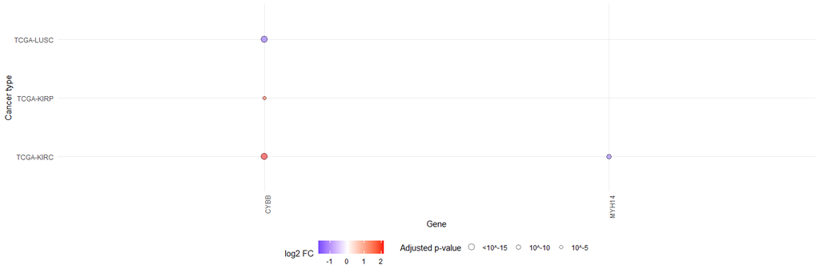

```r
plot_dgea(deseq.bbl.data.combined)
```

#### 10. Immunogenic Cell Death

Fetch the gene set of interest.

```r
genes <- read.csv(paste0(RCDdb, "Immunogenic_cell_death.csv"))
genes$gene_id <- cleanid(genes$gene_id)
genes <- distinct(genes, gene_id, .keep_all = TRUE)
genes <- subset(genes, gene_id != "")
genes
```

|  | deathtype | gene | description | gene_id | gene_biotype | pmid | comment |
| --- | --- | --- | --- | --- | --- | --- | --- |
| 1 | Immunogenic_cell_death | CALR | calreticulin | ENSG00000179218 | protein_coding | 37020026 | The NK cell receptor NKp46 can recognize exocalmodulin and induce NK cells to kill ER stressed cells. CALR knockout or CALR mutation inhibits the binding and killing effect of NKp46-Ig, while CALR-com… |
| 2 | Immunogenic_cell_death | KLRK1 | killer cell lectin like receptor K1 | ENSG00000213809 | protein_coding | 37020026 | Ecto-calreticulin is a marker of cellular stress. T + P treatment (formed by trametinib and palbociclib) induced ER stress and cell aging in KRAS mutant human lung cancer A549, and improved the expres… |
| 3 | Immunogenic_cell_death | HMGB1 | high mobility group box 1 | ENSG00000189403 | protein_coding | 23151605 | HMGB1 plays a key role by binding with beclin 1. Macrophages and monocytes activated by IL-1\xa6\xc2, tumor necrosis factor, or lipopolysaccharide can secrete HMGB1 as a cytokine through the secretion… |
| 4 | Immunogenic_cell_death | HSPA1A | heat shock protein family A (Hsp70) member 1A | ENSG00000204389 | protein_coding | 25964865 | The function of HSP70 is to stimulate anti-tumor immune response through TLR4 signaling pathway through the release of heat shock protein, which is an important supplement to the immunogenic cell deat… |
| 5 | Immunogenic_cell_death | HSPA1B | heat shock protein family A (Hsp70) member 1B | ENSG00000204388 | protein_coding | 25964865 | The function of HSP70 is to stimulate anti-tumor immune response through TLR4 signaling pathway through the release of heat shock protein, which is an important supplement to the immunogenic cell deat… |
| 6 | Immunogenic_cell_death | HSPA1L | heat shock protein family A (Hsp70) member 1 like | ENSG00000204390 | protein_coding | 25964865 | The function of HSP70 is to stimulate anti-tumor immune response through TLR4 signaling pathway through the release of heat shock protein, which is an important supplement to the immunogenic cell deat… |
| 7 | Immunogenic_cell_death | HSP90AA1 | heat shock protein 90 alpha family class A member 1 | ENSG00000080824 | protein_coding | 25964865 | By signaling with Toll-like receptor 4 (TLR4), HSP70 and other heat shock proteins can be released during hyperthermia and then play a major role in tumor-specific immune responses |
| 8 | Immunogenic_cell_death | HSP90AB1 | heat shock protein 90 alpha family class B member 1 | ENSG00000096384 | protein_coding | 25964865 | By signaling with Toll-like receptor 4 (TLR4), HSP70 and other heat shock proteins can be released during hyperthermia and then play a major role in tumor-specific immune responses |
| 9 | Immunogenic_cell_death | HSPA5 | heat shock protein family A (Hsp70) member 5 | ENSG00000044574 | protein_coding | 35658433 | In this study, an iridium (III) ionic complex regulates Immunogenic cell death (ICD) in cells by inducing endoplasmic reticulum stress. Meanwhile, the design of a clickable photoaffinity probe has sho… |
| 10 | Immunogenic_cell_death | CD47 | CD47 molecule | ENSG00000196776 | protein_coding | 35402082 | PKHB1 is a thrombospondin-1 peptide mimic that induces immunogenic cell death in different cancer cells by inducing immunogenic cell death inducers and in breast cancer and T-cell acute lymphoblastic … |

[output cut: 24 more lines]

Filter the genes to include only those in the gene set of interest, and then perform differential gene expression analysis.

```r
deseq.bbl.data.combined <- filter_gene_set_and_perform_dgea(genes)
```

```
[1] "TCGA-LUSC"
[1] "============="
```

```
[1] "TCGA-COAD"
[1] "============="
```

```
[1] "TCGA-KICH"
[1] "============="
```

```
[1] "TCGA-KIRC"
[1] "============="
```

```
[1] "TCGA-PRAD"
[1] "============="
```

```
[1] "TCGA-BRCA"
[1] "============="
```

```
[1] "TCGA-HNSC"
[1] "============="
```

```
[1] "TCGA-KIRP"
[1] "============="
```

```
[1] "TCGA-LIHC"
[1] "============="
```

```
[1] "TCGA-STAD"
[1] "============="
```

```
[1] "TCGA-THCA"
[1] "============="
```

```
[1] "TCGA-BLCA"
[1] "============="
```

```
[1] "TCGA-LUAD"
[1] "============="
```

```
[1] "TCGA-ESCA"
[1] "============="
```

```r
deseq.bbl.data.combined
```

|  | baseMean | log2FoldChange | lfcSE | stat | pvalue | padj | cancer_type | gene_symbol |
| --- | --- | --- | --- | --- | --- | --- | --- | --- |
| ENSG00000136869 | 2810.354261 | -2.111141 | 0.1549047 | -13.628641 | 2.705726e-42 | 5.682024e-41 | TCGA-LUSC | TLR4 |
| ENSG00000162772...2 | 8983.184157 | -1.618502 | 0.2487794 | -6.505771 | 7.729597e-11 | 1.352679e-10 | TCGA-LUSC | ATF3 |
| ENSG00000164342...3 | 1080.968780 | -1.706956 | 0.1500080 | -11.379106 | 5.314156e-30 | 5.579864e-29 | TCGA-LUSC | TLR3 |
| ENSG00000164342...4 | 982.147539 | -2.119905 | 0.1731113 | -12.245906 | 1.766918e-34 | 3.710527e-33 | TCGA-COAD | TLR3 |
| ENSG00000175197 | 3750.996087 | 2.533890 | 0.2109709 | 12.010615 | 3.125136e-33 | 6.875299e-32 | TCGA-KICH | DDIT3 |
| ENSG00000228083...6 | 2.659094 | -4.546719 | 0.6733334 | -6.752552 | 1.452671e-11 | 5.326461e-11 | TCGA-KICH | IFNA14 |
| ENSG00000162772...7 | 7949.020791 | -1.520557 | 0.2312514 | -6.575341 | 4.854188e-11 | 9.708375e-11 | TCGA-KIRC | ATF3 |
| ENSG00000164342...8 | 5399.914295 | 1.801287 | 0.1126248 | 15.993694 | 1.413932e-57 | 3.110651e-56 | TCGA-KIRC | TLR3 |
| ENSG00000213809 | 10.217189 | 2.134546 | 0.2300801 | 9.277404 | 1.736585e-20 | 5.457839e-20 | TCGA-KIRC | KLRK1 |
| ENSG00000228083...10 | 2.951783 | -4.688726 | 0.4996776 | -9.383502 | 6.381723e-21 | 2.339965e-20 | TCGA-KIRC | IFNA14 |

[output cut: 11 more lines]

Plot the results.

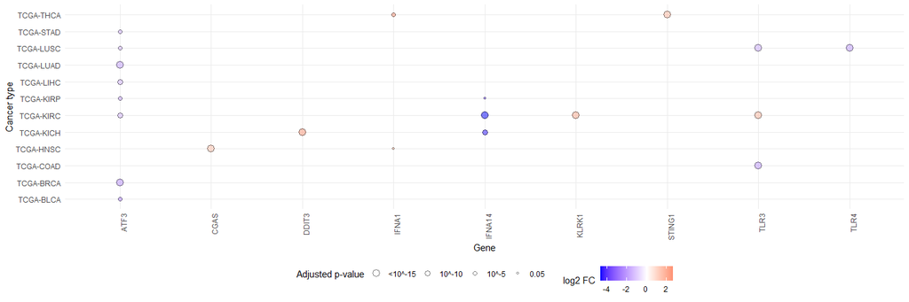

```r
plot_dgea(deseq.bbl.data.combined)
```

#### 11. Lysosome-Dependent Cell Death

Fetch the gene set of interest.

```r
genes <- read.csv(paste0(RCDdb, "Lysosome_dependent_cell_death.csv"))
genes$gene_id <- cleanid(genes$gene_id)
genes <- distinct(genes, gene_id, .keep_all = TRUE)
genes <- subset(genes, gene_id != "")
genes
```

|  | deathtype | gene | description | gene_id | gene_biotype | pmid | comment |
| --- | --- | --- | --- | --- | --- | --- | --- |
| 1 | Lysosome_dependent_cell_death | AP3B1 | adaptor related protein complex 3 subunit beta 1 | ENSG00000132842 | protein_coding | 14566336 | AP3B1 is a subunit of the AP-3 complex and is related to lysosome dependent cell death. The loss of AP-3 in HPS2 patients leads to the inability of CTLs (cytotoxic T lymphocytes) to perform lysosome d… |
| 2 | Lysosome_dependent_cell_death | ASAH1 | N-acylsphingosine amidohydrolase 1 | ENSG00000104763 | protein_coding | 33221496 | The study found that the deletion of the Asah1 gene resulted in a significant reduction in LAMP-1 in podocyte-specific Asah1 gene knockout mice, indicating that Asah1 deletion caused an overload of ly… |
| 3 | Lysosome_dependent_cell_death | ATP6V0A2 | ATPase H+ transporting V0 subunit a2 | ENSG00000185344 | protein_coding | 32234325 | ATP6V0A2 is a subunit embedded in the lysosomal membrane, involved in regulating its acidification process. During H1N1 infection, the active form of ATP6V0A2 is reduced, which may be related to a dec… |
| 4 | Lysosome_dependent_cell_death | ATP6V1H | ATPase H+ transporting V1 subunit H | ENSG00000047249 | protein_coding | 33966596 | The study shows that overexpression of CREG1 promotes the expression and acidification of ATP6V1H, which helps to accelerate lysosome-mediated protein degradation and autophagy pathway. |
| 5 | Lysosome_dependent_cell_death | CTSL | cathepsin L | ENSG00000135047 | protein_coding | 29362479 | TSL (cathepsin L) is related to Lysosome dependent cell death by promoting the permeability of primary lysosome membranes. |
| 6 | Lysosome_dependent_cell_death | BAX | BCL2 associated X, apoptosis regulator | ENSG00000087088 | protein_coding | 29362479 | In some situations, BAX can interact with lysosomal membrane and activate the pores formed on it, leading to primary lysosomal membrane permeabilization and cell lysis, thus participating in Lysosome-… |
| 7 | Lysosome_dependent_cell_death | DRAM1 | DNA damage regulated autophagy modulator 1 | ENSG00000136048 | protein_coding | 29362479 | It is a p53 effector and a modulator of autophagy. In HIV1-infected T cells, DRAM1 provided a major contribution to Lysosome-dependent cell death by linking LMP to MOMP. |
| 8 | Lysosome_dependent_cell_death | HSPA1A | heat shock protein family A (Hsp70) member 1A | ENSG00000204389 | protein_coding | 29362479 | Involvement of HSPA1A in lysosome-dependent cell death occurs through enhancing stabilization of lysosomal membranes. By increasing the activity of HSP70, or through administration of recombinant HSP7… |
| 9 | Lysosome_dependent_cell_death | PRTN3 | proteinase 3 | ENSG00000196415 | protein_coding | 29362479 | In Lysosome dependent cell death, PRTN3 participates in the process of cell death by catalyzing the proteolytic activation of CASP3 |
| 10 | Lysosome_dependent_cell_death | CTSB | cathepsin B | ENSG00000164733 | protein_coding | 29362479 | CTSB is a member of the cathepsin family and is an extremely important protease in the cytoplasm and intramembrane system which participates in the degradation of extracellular proteins, adhesion plaq… |

[output cut: 22 more lines]

Filter the genes to include only those in the gene set of interest, and then perform differential gene expression analysis.

```r
deseq.bbl.data.combined <- filter_gene_set_and_perform_dgea(genes)
```

```
[1] "TCGA-LUSC"
[1] "============="
```

```
[1] "TCGA-COAD"
[1] "============="
```

```
[1] "TCGA-KICH"
[1] "============="
```

```
[1] "TCGA-KIRC"
[1] "============="
```

```
[1] "TCGA-PRAD"
[1] "============="
```

```
[1] "TCGA-BRCA"
[1] "============="
```

```
[1] "TCGA-HNSC"
[1] "============="
```

```
[1] "TCGA-KIRP"
[1] "============="
```

```
[1] "TCGA-LIHC"
[1] "============="
```

```
[1] "TCGA-STAD"
[1] "============="
```

```
[1] "TCGA-THCA"
[1] "============="
```

```
[1] "TCGA-BLCA"
[1] "============="
```

```
[1] "TCGA-LUAD"
[1] "============="
```

```
[1] "TCGA-ESCA"
[1] "============="
```

```r
deseq.bbl.data.combined
```

|  | baseMean | log2FoldChange | lfcSE | stat | pvalue | padj | cancer_type | gene_symbol |
| --- | --- | --- | --- | --- | --- | --- | --- | --- |
| ENSG00000067225...1 | 91816.249234 | 1.554529 | 0.09315624 | 16.687329 | 1.620607e-62 | 2.592971e-61 | TCGA-LUSC | PKM |
| ENSG00000104763 | 23153.470762 | -1.701514 | 0.11280659 | -15.083461 | 2.080705e-51 | 2.219419e-50 | TCGA-LUSC | ASAH1 |
| ENSG00000136048 | 9349.642408 | -2.372422 | 0.13513164 | -17.556380 | 5.315912e-69 | 1.701092e-67 | TCGA-LUSC | DRAM1 |
| ENSG00000146648...4 | 21561.037059 | 2.052682 | 0.23158096 | 8.863779 | 7.734716e-19 | 4.125182e-18 | TCGA-LUSC | EGFR |
| ENSG00000196415...5 | 5.287093 | -1.855434 | 0.37514043 | -4.945972 | 7.576494e-07 | 2.020398e-06 | TCGA-LUSC | PRTN3 |
| ENSG00000117984 | 82652.448320 | 2.061720 | 0.18714739 | 11.016560 | 3.179792e-28 | 3.285785e-27 | TCGA-KICH | CTSD |
| ENSG00000121858 | 6253.350254 | -2.492909 | 0.20932992 | -11.908993 | 1.062526e-32 | 1.646915e-31 | TCGA-KICH | TNFSF10 |
| ENSG00000204389 | 2786.178287 | -1.779477 | 0.29532253 | -6.025536 | 1.685499e-09 | 7.464352e-09 | TCGA-KICH | HSPA1A |
| ENSG00000146648...9 | 18104.612948 | 1.804957 | 0.12140011 | 14.867836 | 5.330883e-50 | 8.529412e-49 | TCGA-KIRC | EGFR |
| ENSG00000196415...10 | 6.561634 | 1.879489 | 0.37217816 | 5.049972 | 4.418744e-07 | 9.426653e-07 | TCGA-KIRC | PRTN3 |

[output cut: 12 more lines]

Plot the results.

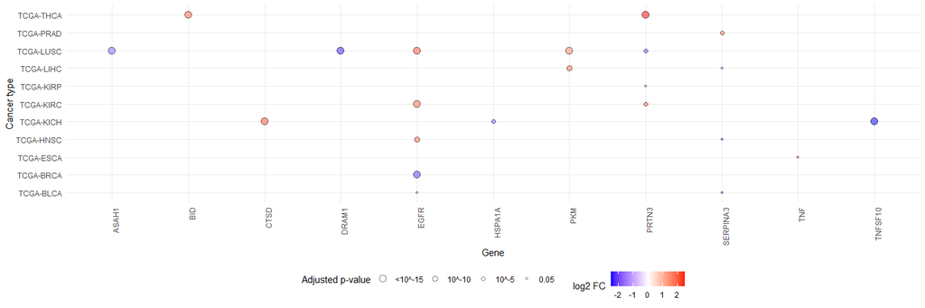

```r
plot_dgea(deseq.bbl.data.combined)
```

#### 12. MPT-Driven Necrosis

Fetch the gene set of interest.

```r
genes <- read.csv(paste0(RCDdb, "MPT_driven_necrosis.csv"))
genes$gene_id <- cleanid(genes$gene_id)
genes <- distinct(genes, gene_id, .keep_all = TRUE)
genes <- subset(genes, gene_id != "")
genes
```

|  | deathtype | gene | description | gene_id | gene_biotype | pmid | comment |
| --- | --- | --- | --- | --- | --- | --- | --- |
| 1 | MPT_driven_necrosis | ATP5F1A | ATP synthase F1 subunit alpha | ENSG00000152234 | protein_coding | 30874894 | ATP5A1 is a subunit of mitochondrial ATP synthase complex V, while MPT is the mitochondrial permeability transition pore, whose opening is one of the important mechanisms leading to necrosis. The stud… |
| 2 | MPT_driven_necrosis | ATP5F1B | ATP synthase F1 subunit beta | ENSG00000110955 | protein_coding | 30244272 | ATP5B is associated with MPT-driven necrosis. By inhibiting ATP synthesis, the ATP synthase complex of ATP5B increases the opening of mitochondrial permeability transition (MPT), causing mitochondrial… |
| 3 | MPT_driven_necrosis | CAPN1 | calpain 1 | ENSG00000014216 | protein_coding | 30874894 | Localized CAPN1 to mitochondria contributes to the stimulation of mitochondrial superoxide generation, which leads to the initiation of mPTP and subsequently induces cell death. |
| 4 | MPT_driven_necrosis | ROCK1 | Rho associated coiled-coil containing protein kinase 1 | ENSG00000067900 | protein_coding | 25305180 | ROCK1 participates in the MPT-driven necrosis during myocardial ischemia-reperfusion (I/R) injury. |
| 5 | MPT_driven_necrosis | ATP5PF | ATP synthase peripheral stalk subunit F6 | ENSG00000154723 | protein_coding | 33937399 | ATP5J protein participates in ER stress and mitochondrial membrane potential, and thus is involved in cell necrosis caused by MPT. |
| 6 | MPT_driven_necrosis | SPG7 | SPG7 matrix AAA peptidase subunit, paraplegin | ENSG00000197912 | protein_coding | 26387735 | SPG7 has been identified as a crucial component of the mitochondrial permeability transition pore (PTP) complex and is responsible for regulating its function. The researchers found that the loss of S… |
| 7 | MPT_driven_necrosis | PPIF | Peptidylprolyl Isomerase F | ENSG00000108179 | protein_coding | 17417626 | localized CAPN1 to mitochondria contributes to the stimulation of mitochondrial superoxide generation, which leads to the initiation of mPTP and subsequently induces cell death. |
| 8 | MPT_driven_necrosis | NLRP3 | NLR family pyrin domain containing 3 | ENSG00000162711 | protein_coding | 34718331 | Our mechanistic studies reveal that Mtb triggers mitochondrial permeability transition (mPT) and subsequently extensive macrophage necrosis, which requires activation of the NLRP3 inflammasome. NLRP3-… |
| 9 | MPT_driven_necrosis | BID | BH3 interacting domain death agonist | ENSG00000015475 | protein_coding | 17417626 | BID is involved in MPT-driven necrosis. Endogenous Bax and Bid activation catalyzes cytochrome c release and cooperatively induces cell death. |
| 10 | MPT_driven_necrosis | BCL2L11 | BCL2 like 11 | ENSG00000153094 | protein_coding | 25143432 | BIRO1 derived from the BCL2L11 death domain is effective in promoting retinoblastoma cell death by initiating mitochondrial fragmentation. The interaction between BIRO1 and BCL2L11 decreases the BCL2L… |

[output cut: 20 more lines]

Filter the genes to include only those in the gene set of interest, and then perform differential gene expression analysis.

```r
deseq.bbl.data.combined <- filter_gene_set_and_perform_dgea(genes)
```

```
[1] "TCGA-LUSC"
[1] "============="
```

```
[1] "TCGA-COAD"
[1] "============="
```

```
[1] "TCGA-KICH"
[1] "============="
```

```
[1] "TCGA-KIRC"
[1] "============="
```

```
[1] "TCGA-PRAD"
[1] "============="
```

```
[1] "TCGA-BRCA"
[1] "============="
```

```
[1] "TCGA-HNSC"
[1] "============="
```

```
[1] "TCGA-KIRP"
[1] "============="
```

```
[1] "TCGA-LIHC"
[1] "============="
```

```
[1] "TCGA-STAD"
[1] "============="
```

```
[1] "TCGA-THCA"
[1] "============="
```

```
[1] "TCGA-BLCA"
[1] "============="
```

```
[1] "TCGA-LUAD"
[1] "============="
```

```
[1] "TCGA-ESCA"
[1] "============="
```

```r
deseq.bbl.data.combined
```

|  | baseMean | log2FoldChange | lfcSE | stat | pvalue | padj | cancer_type | gene_symbol |
| --- | --- | --- | --- | --- | --- | --- | --- | --- |
| ENSG00000108179 | 4734.577321 | 1.544752 | 0.13181297 | 11.719269 | 1.015446e-31 | 1.015446e-30 | TCGA-LUSC | PPIF |
| ENSG00000109819...2 | 650.765864 | -1.598190 | 0.23518287 | -6.795522 | 1.079208e-11 | 1.798680e-11 | TCGA-LUSC | PPARGC1A |
| ENSG00000135116...3 | 91.189243 | 1.566107 | 0.33720812 | 4.644334 | 3.411749e-06 | 4.652385e-06 | TCGA-LUSC | HRK |
| ENSG00000137875...4 | 50.739565 | 4.572959 | 0.31834718 | 14.364690 | 8.619176e-47 | 2.585753e-45 | TCGA-LUSC | BCL2L10 |
| ENSG00000141682...5 | 1411.672336 | 2.233282 | 0.18866813 | 11.837092 | 2.510058e-32 | 3.765087e-31 | TCGA-LUSC | PMAIP1 |
| ENSG00000162711...6 | 618.897694 | -1.945226 | 0.21002787 | -9.261749 | 2.011098e-20 | 1.005549e-19 | TCGA-LUSC | NLRP3 |
| ENSG00000109819...7 | 961.739200 | -1.506706 | 0.23343532 | -6.454489 | 1.085845e-10 | 3.431948e-10 | TCGA-COAD | PPARGC1A |
| ENSG00000135116...8 | 19.051561 | -2.696489 | 0.32844021 | -8.209983 | 2.212194e-16 | 1.327316e-15 | TCGA-COAD | HRK |
| ENSG00000141682...9 | 352.731426 | 2.212803 | 0.15280964 | 14.480784 | 1.602598e-47 | 4.807793e-46 | TCGA-COAD | PMAIP1 |
| ENSG00000169100 | 55196.219632 | 1.514735 | 0.23496699 | 6.446585 | 1.143983e-10 | 3.431948e-10 | TCGA-COAD | SLC25A6 |

[output cut: 26 more lines]

Plot the results.

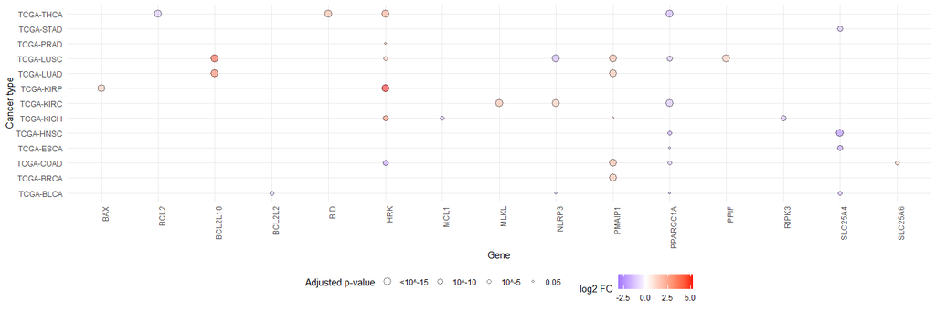

```r
plot_dgea(deseq.bbl.data.combined)
```

#### 13. NETotic Cell Death

Fetch the gene set of interest.

```r
genes <- read.csv(paste0(RCDdb, "NETotic_cell_death.csv"))
genes$gene_id <- cleanid(genes$gene_id)
genes <- distinct(genes, gene_id, .keep_all = TRUE)
genes <- subset(genes, gene_id != "")
genes
```

|  | deathtype | gene | description | gene_id | gene_biotype | pmid | comment |
| --- | --- | --- | --- | --- | --- | --- | --- |
| 1 | NETotic_cell_death | ELANE | elastase, neutrophil expressed | ENSG00000197561 | protein_coding | 29150539 | In long-term (2-4 hour) 100 nM PMA stimulation, ELANE can promote F-actin degradation, releasing proteases into the nucleus . This suggests a specific role of ELANE in NET formation. |
| 2 | NETotic_cell_death | MPO | myeloperoxidase | ENSG00000005381 | protein_coding | 20974816 | Intracellular ROS would drive NETotic cell death (1) by triggering the release of elastase, neutrophil expressed (ELANE), and myeloperoxidase (MPO) from neutrophil granules to the cytosol, followed by… |
| 3 | NETotic_cell_death | CAMP | cathelicidin antimicrobial peptide | ENSG00000164047 | protein_coding | 30948788 | NETosis is a dynamic process and relies on multiple signals and steps including NADPH oxidase-mediated ROS production, autophagy, the release and translocation of granular enzymes (e.g., elastase, neu… |
| 4 | NETotic_cell_death | PADI4 | peptidyl arginine deiminase 4 | ENSG00000159339 | protein_coding | 20733033 | Histone hypercitrullination mediated by PADI4 is the prerequisite for chromatin decondensation, which is necessary for NET formation. It has been proved by experiments that PADI4 depletion leads to a … |
| 5 | NETotic_cell_death | SLC8A1 | solute carrier family 8 member A1 | ENSG00000183023 | protein_coding | 33933883 | By using amiloride derivatives EIPA and MIA to inhibit the forward Na+/Ca2+ exchange, it was found that NCX-dependent interstitial cell Ca2+ signaling can be triggered, leading to intracellular ROS ac… |
| 6 | NETotic_cell_death | RAF1 | Raf-1 proto-oncogene, serine/threonine kinase | ENSG00000132155 | protein_coding | 29362479 | NETotic cell death has been suggested to result from a signaling pathway that involves Raf-1 proto-oncogene, serine/threonine kinase (RAF1), mitogen-activated protein kinase kinases (MAP2Ks), and ERK2… |
| 7 | NETotic_cell_death | CSF3 | colony stimulating factor 3 | ENSG00000108342 | protein_coding | 27994595 | CSF3 not only helps increase neutrophil counts during pregnancy but also promotes progressively enhanced NETosis. The experimental results indicate that CSF3 is an important contributor to the pro-NET… |
| 8 | NETotic_cell_death | AURKA | aurora kinase A | ENSG00000087586 | protein_coding | 30948788 | AURKA promotes Netotic cell death by controlling microtubule plasticity. |

Filter the genes to include only those in the gene set of interest, and then perform differential gene expression analysis.

```r
deseq.bbl.data.combined <- filter_gene_set_and_perform_dgea(genes)
```

```
[1] "TCGA-LUSC"
[1] "============="
```

```
[1] "TCGA-COAD"
[1] "============="
```

```
[1] "TCGA-KICH"
[1] "============="
```

```
[1] "TCGA-KIRC"
[1] "============="
```

```
[1] "TCGA-PRAD"
[1] "============="
```

```
[1] "TCGA-BRCA"
[1] "============="
```

```
[1] "TCGA-HNSC"
[1] "============="
```

```
[1] "TCGA-KIRP"
[1] "============="
```

```
[1] "TCGA-LIHC"
[1] "============="
```

```
[1] "TCGA-STAD"
[1] "============="
```

```
[1] "TCGA-THCA"
[1] "============="
```

```
[1] "TCGA-BLCA"
[1] "============="
```

```
[1] "TCGA-LUAD"
[1] "============="
```

```
[1] "TCGA-ESCA"
[1] "============="
```

```r
deseq.bbl.data.combined
```

|  | baseMean | log2FoldChange | lfcSE | stat | pvalue | padj | cancer_type | gene_symbol |
| --- | --- | --- | --- | --- | --- | --- | --- | --- |
| ENSG00000087586...1 | 1541.878823 | 3.906850 | 0.1666344 | 23.445632 | 1.464726e-121 | 1.171781e-120 | TCGA-LUSC | AURKA |
| ENSG00000108342...2 | 2676.933934 | -3.248238 | 0.4672156 | -6.952331 | 3.592985e-12 | 5.748776e-12 | TCGA-LUSC | CSF3 |
| ENSG00000159339...3 | 76.692473 | -3.155266 | 0.2647088 | -11.919762 | 9.337453e-33 | 3.734981e-32 | TCGA-LUSC | PADI4 |
| ENSG00000164047...4 | 94.641643 | -2.539691 | 0.3244083 | -7.828685 | 4.929986e-15 | 9.859972e-15 | TCGA-LUSC | CAMP |
| ENSG00000197561...5 | 19.053335 | -2.413331 | 0.2396981 | -10.068211 | 7.635462e-24 | 2.036123e-23 | TCGA-LUSC | ELANE |
| ENSG00000197561...6 | 18.953807 | -3.100773 | 0.2614207 | -11.861237 | 1.881741e-32 | 1.505393e-31 | TCGA-COAD | ELANE |
| ENSG00000005381...7 | 20.984678 | -2.032134 | 0.4157760 | -4.887571 | 1.020879e-06 | 2.041759e-06 | TCGA-KICH | MPO |
| ENSG00000087586...8 | 528.632904 | 1.962661 | 0.2496352 | 7.862116 | 3.776974e-15 | 3.021579e-14 | TCGA-KICH | AURKA |
| ENSG00000108342...9 | 41.192419 | -4.509261 | 0.6851539 | -6.581384 | 4.660896e-11 | 1.864359e-10 | TCGA-KICH | CSF3 |
| ENSG00000159339...10 | 21.117344 | -1.748759 | 0.4803861 | -3.640321 | 2.722983e-04 | 3.111980e-04 | TCGA-KICH | PADI4 |

[output cut: 32 more lines]

Plot the results.

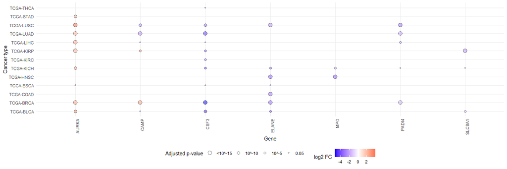

```r
plot_dgea(deseq.bbl.data.combined)
```

#### 14. Oxeiptosis

Fetch the gene set of interest.

```r
genes <- read.csv(paste0(RCDdb, "Oxeiptosis.csv"))
genes$gene_id <- cleanid(genes$gene_id)
genes <- distinct(genes, gene_id, .keep_all = TRUE)
genes <- subset(genes, gene_id != "")
genes
```

|  | deathtype | gene | description | gene_id | gene_biotype | pmid | comment |
| --- | --- | --- | --- | --- | --- | --- | --- |
| 1 | Oxeiptosis | PGAM5 | PGAM family member 5, mitochondrial serine/threonine protein phosphatase | ENSG00000247077 | protein_coding | 29844568 | PGAM5, a mitochondrial serine-threonine phosphatase, participates in the activation of a novel signaling pathway that couples a reactive oxygen species (ROS) sensor to a cytotoxic program. The KEAP1-P… |
| 2 | Oxeiptosis | KEAP1 | kelch like ECH associated protein 1 | ENSG00000079999 | protein_coding | 29844568 | KEAP1 functions as a critical switch that quantitatively monitors intracellular ROS levels. Oxidation of cysteine residues in KEAP1 by ROS triggers conformational changes and leads to the release of t… |
| 3 | Oxeiptosis | AIFM1 | apoptosis inducing factor mitochondria associated 1 | ENSG00000156709 | protein_coding | 29844568 | Mass spectrometry identified that AIFM1 is among the cellular interaction partners of PGAM5, a key downstream effector of oxeiptosis. Knockdown experiments of AIFM1 alone or in combination with PGAM5 … |
| 4 | Oxeiptosis | NFE2L1 | NFE2 like bZIP transcription factor 1 | ENSG00000082641 | protein_coding | 36626243 | Nrf2 is involved in the inhibition of Oxeiptosis and resizes the effect of ROS on cells by regulating the expression of PGAM5 and AIFM1. |
| 5 | Oxeiptosis | GPX4 | glutathione peroxidase 4 | ENSG00000167468 | protein_coding | 29255269 | GPX4 is an antioxidant enzyme that can degrade ROS and prevent their accumulation. Decreased GPX4 activity under conditions of deficiency may promote the occurrence of Oxeiptosis. |
| 6 | Oxeiptosis | OTUD1 | OTU deubiquitinase 1 | ENSG00000165312 | protein_coding | 35941131 | OTUD1 directly interacts with KEAP1 and regulates its K63-ubiquitination, thereby counteracting ROS production and Oxeiptosis. The deficiency of OTUD1 results in mitochondrial damage and increased ROS… |
| 8 | Oxeiptosis | CASP3 | caspase 3 | ENSG00000164305 | protein_coding | 35263194 | Alloimperatorin can activate CASP3 (caspase-3) to promote the dephosphorylation of AIFM1, which leads to oxeipotic cell death, a form of Oxeiptosis. |
| 9 | Oxeiptosis | SOD1 | superoxide dismutase 1 | ENSG00000142168 | protein_coding | 30948788 | SOD1 is a superoxide dismutase that clears superoxide radicals inside the cell. Oxeiptosis is a ROS-dependent, apoptosis-like, non-caspase protease-mediated cell death pathway. In H2O2-induced Oxeipto… |
| 10 | Oxeiptosis | SOD2 | superoxide dismutase 2 | ENSG00000291237 | protein_coding | 30948788 | SOD2 (Superoxide dismutase 2) is an antioxidant enzyme in mitochondria that plays a protective role in Oxeiptosis. |

Filter the genes to include only those in the gene set of interest, and then perform differential gene expression analysis.

```r
deseq.bbl.data.combined <- filter_gene_set_and_perform_dgea(genes)
```

```
[1] "TCGA-LUSC"
[1] "============="
```

```
[1] "TCGA-COAD"
[1] "============="
```

```
[1] "TCGA-KICH"
[1] "============="
```

```
[1] "TCGA-KIRC"
[1] "============="
```

```
[1] "TCGA-PRAD"
[1] "============="
```

```
[1] "TCGA-BRCA"
[1] "============="
```

```
[1] "TCGA-HNSC"
[1] "============="
```

```
[1] "TCGA-KIRP"
[1] "============="
```

```
[1] "TCGA-LIHC"
[1] "============="
```

```
[1] "TCGA-STAD"
[1] "============="
```

```
[1] "TCGA-THCA"
[1] "============="
```

```
[1] "TCGA-BLCA"
[1] "============="
```

```
[1] "TCGA-LUAD"
[1] "============="
```

```
[1] "TCGA-ESCA"
[1] "============="
```

```r
deseq.bbl.data.combined
```

|  | baseMean | log2FoldChange | lfcSE | stat | pvalue | padj | cancer_type | gene_symbol |
| --- | --- | --- | --- | --- | --- | --- | --- | --- |
| ENSG00000165312...1 | 3294.123 | -1.949152 | 0.1556708 | -12.52099 | 5.731877e-36 | 4.585502e-35 | TCGA-LUSC | OTUD1 |
| ENSG00000165312...2 | 1832.997 | -2.022227 | 0.1362468 | -14.84238 | 7.793514e-50 | 6.234811e-49 | TCGA-LUAD | OTUD1 |

Plot the results.

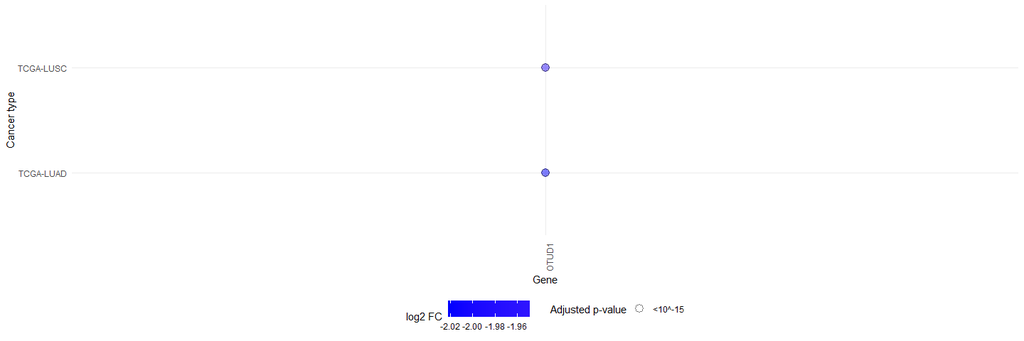

```r
plot_dgea(deseq.bbl.data.combined)
```

#### 15. Parthanatos

Fetch the gene set of interest.

```r
genes <- read.csv(paste0(RCDdb, "Parthanatos.csv"))
genes$gene_id <- cleanid(genes$gene_id)
genes <- distinct(genes, gene_id, .keep_all = TRUE)
genes <- subset(genes, gene_id != "")
genes
```

|  | deathtype | gene | description | gene_id | gene_biotype | pmid | comment |
| --- | --- | --- | --- | --- | --- | --- | --- |
| 1 | Parthanatos | PARP1 | poly(ADP-ribose) polymerase 1 | ENSG00000143799 | protein_coding | 32251407 | Studies have shown that by inhibiting the activity of PARP1, it is possible to change the mechanism of cell death caused by MNNG-camptothecin from parthanatotic to apoptotic. This suggests that PARP1 … |
| 2 | Parthanatos | MIF | macrophage migration inhibitory factor | ENSG00000240972 | protein_coding | 35545089 | As a part of PAAN/MIF nuclease, MIF mediates the large-scale DNA fragmentation in the process of Parthanatos. Neutralizing the nuclease activity of PAAN/MIF can protect dopaminergic neurons from the P… |
| 3 | Parthanatos | AIFM1 | apoptosis inducing factor mitochondria associated 1 | ENSG00000156709 | protein_coding | 27817117 | In comparing the mechanisms of cell death in progressive multifocal leukoencephalopathy (PML), the disease induces cells to die by virus-induced PARP and AIFM1 transport, a process known as Parthanato… |
| 4 | Parthanatos | HSPA4 | heat shock protein family A (Hsp70) member 4 | ENSG00000170606 | protein_coding | 37060999 | Reactive sulfur species prevent Parthanatos by inhibiting the p62-based aggresome-like induced structures formation through the induction of HSP70, which is a member of the heat shock protein 70 famil… |
| 5 | Parthanatos | ADPRS | ADP-ribosylserine hydrolase [Homo sapiens | ENSG00000116863 | protein_coding | 33171306 | Under oxidative stress conditions, ARH3-deficient cells show increased PAR accumulation and PARP1-mediated cell death, which plays an important role in regulating the growth of various tumors. |
| 6 | Parthanatos | RNF146 | ring finger protein 146 | ENSG00000118518 | protein_coding | 33443209 | RNF146 inhibits the parthanatos cell death pathway by inhibiting the overactivation of PARP1. Activation of the Akt1-CREB-RNF146 pathway can increase the survival of cultured cells in the presence of … |
| 7 | Parthanatos | OGG1 | 8-oxoguanine DNA glycosylase | ENSG00000114026 | protein_coding | 29795387 | Genetic or siRNA-mediated ablation of Ogg1, as well as the expression of enzymatically deficient OGG1, decreased the accumulation of DNA strand breaks, PARP1 overactivation, and AIF nuclear translocat… |
| 8 | Parthanatos | HSF1 | heat shock transcription factor 1 | ENSG00000185122 | protein_coding | 37060999 | Na2S4 activates HSF1 and promotes its dissociation from HSP90, leading to the accelerated transcription of HSP70. Conversely, the inhibitors of RSS-producing enzymes, such as 3-mercaptopyruvate sulfur… |
| 9 | Parthanatos | HSP90AA1 | heat shock protein 90 alpha family class A member 1 | ENSG00000080824 | protein_coding | 37060999 | Na2S4 promotes the persulfidation of Hsp90-Cys521, leading to dissociation of Hsp90 from HSF1 and subsequent activation of HSF1 and HSP70 transcription. Ultimately, the upregulated HSP70 promotes the … |
| 10 | Parthanatos | PARG | poly(ADP-ribose) glycohydrolase | ENSG00000227345 | protein_coding | 24191052 | PARG participates in the mechanism of Parthanatos by catalyzing the hydrolysis of PAR on PARP1 to generate protein-free PAR molecules, which act as signals to release AIF from mitochondrial membranes. |

Filter the genes to include only those in the gene set of interest, and then perform differential gene expression analysis.

```r
deseq.bbl.data.combined <- filter_gene_set_and_perform_dgea(genes)
```

```
[1] "TCGA-LUSC"
[1] "============="
```

```
[1] "TCGA-COAD"
[1] "============="
```

```
[1] "TCGA-KICH"
[1] "============="
```

```
[1] "TCGA-KIRC"
[1] "============="
```

```
[1] "TCGA-PRAD"
[1] "============="
```

```
[1] "TCGA-BRCA"
[1] "============="
```

```
[1] "TCGA-HNSC"
[1] "============="
```

```
[1] "TCGA-KIRP"
[1] "============="
```

```
[1] "TCGA-LIHC"
[1] "============="
```

```
[1] "TCGA-STAD"
[1] "============="
```

```
[1] "TCGA-THCA"
[1] "============="
```

```
[1] "TCGA-BLCA"
[1] "============="
```

```
[1] "TCGA-LUAD"
[1] "============="
```

```
[1] "TCGA-ESCA"
[1] "============="
```

```r
deseq.bbl.data.combined
```

|  | baseMean | log2FoldChange | lfcSE | stat | pvalue | padj | cancer_type | gene_symbol |
| --- | --- | --- | --- | --- | --- | --- | --- | --- |
| ENSG00000240972 | 12.80524 | 6.368891 | 0.7637411 | 8.33907 | 7.487735e-17 | 7.487735e-16 | TCGA-COAD | MIF |

Plot the results.

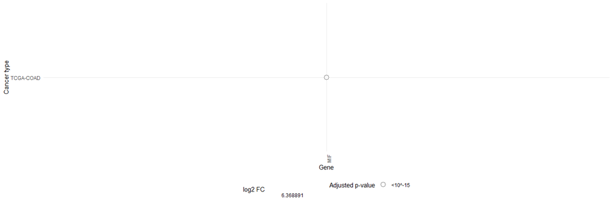

```r
plot_dgea(deseq.bbl.data.combined)
```

[^1]: De La Salle University, Manila, Philippines, gonzales.markedward@gmail.com
[^2]: De La Salle University, Manila, Philippines, anish.shrestha@dlsu.edu.ph